# Necessary conditions analysis (NCA)

#### **Figure**

#### *NCA Plot: FFT indicators - VA_BAM_std*

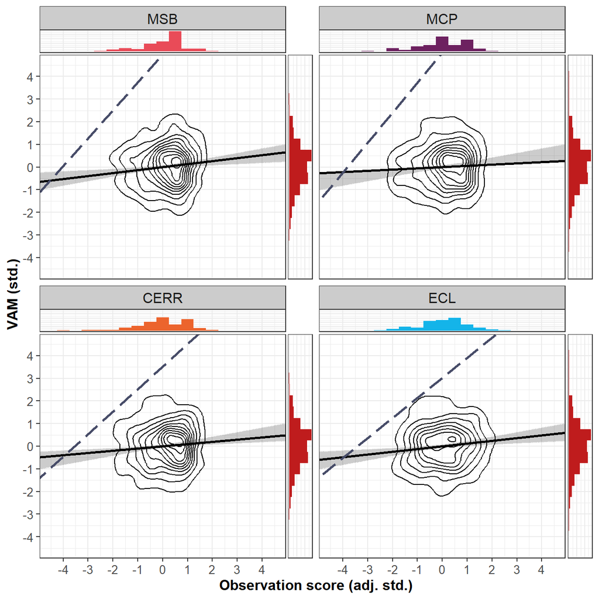

Bottlenecks (expressed as actual values)

| VA_BAM_std | cr_fdh FFT_CEV_adj_std | cr_fdh FFT_MSB_adj_std | cr_fdh FFT_MCP_adj_std | cr_fdh FFT_CERR_adj_std | cr_fdh FFT_ECL_adj_std |
| --- | --- | --- | --- | --- | --- |
| -3.0 | NN | NN | NN | NN | NN |
| -2.5 | NN | NN | NN | NN | NN |
| -2.0 | NN | NN | NN | NN | NN |
| -1.5 | NN | NN | NN | NN | NN |
| -1.0 | NN | NN | -4.577 | NN | NN |
| -0.5 | -4.312 | NN | -4.200 | -4.049 | -3.987 |
| 0.0 | -3.807 | -4.051 | -3.823 | -3.546 | -3.422 |
| 0.5 | -3.303 | -3.645 | -3.446 | -3.043 | -2.857 |
| 1.0 | -2.798 | -3.239 | -3.069 | -2.540 | -2.292 |
| 1.5 | -2.294 | -2.832 | -2.692 | -2.037 | -1.727 |
| 2.0 | -1.789 | -2.426 | -2.315 | -1.534 | -1.162 |
| 2.5 | -1.284 | -2.020 | -1.938 | -1.031 | -0.597 |
| 3.0 | -0.780 | -1.613 | -1.561 | -0.528 | -0.032 |
| 3.5 | -0.275 | -1.207 | -1.183 | -0.025 | 0.533 |

Note. Data from 642 classrooms is included. NN = Not necessary.

Bottlenecks (expressed as percentage range)

| VA_BAM_std | cr_fdh FFT_CEV_adj_std | cr_fdh FFT_MSB_adj_std | cr_fdh FFT_MCP_adj_std | cr_fdh FFT_CERR_adj_std | cr_fdh FFT_ECL_adj_std |
| --- | --- | --- | --- | --- | --- |
| -3.0 | NN | NN | NN | NN | NN |
| -2.5 | NN | NN | NN | NN | NN |
| -2.0 | NN | NN | NN | NN | NN |
| -1.5 | NN | NN | NN | NN | NN |
| -1.0 | NN | NN | 4.1 | NN | NN |
| -0.5 | 5.7 | NN | 9.4 | 2.7 | 0.8 |
| 0.0 | 13.2 | 2.3 | 14.7 | 10.6 | 8.8 |
| 0.5 | 20.7 | 8.7 | 20.1 | 18.6 | 16.8 |
| 1.0 | 28.2 | 15.1 | 25.4 | 26.6 | 24.8 |
| 1.5 | 35.6 | 21.5 | 30.7 | 34.5 | 32.7 |
| 2.0 | 43.1 | 27.9 | 36.0 | 42.5 | 40.7 |
| 2.5 | 50.6 | 34.3 | 41.4 | 50.5 | 48.7 |
| 3.0 | 58.1 | 40.7 | 46.7 | 58.5 | 56.7 |
| 3.5 | 65.6 | 47.1 | 52.0 | 66.4 | 64.7 |

Note. Data from 642 classrooms is included. NN = Not necessary.

Bottlenecks (expressed as percentiles)

| VA_BAM_std | cr_fdh FFT_CEV_adj_std | cr_fdh FFT_MSB_adj_std | cr_fdh FFT_MCP_adj_std | cr_fdh FFT_CERR_adj_std | cr_fdh FFT_ECL_adj_std |
| --- | --- | --- | --- | --- | --- |
| -3.0 | NN | NN | NN | NN | NN |
| -2.5 | NN | NN | NN | NN | NN |
| -2.0 | NN | NN | NN | NN | NN |
| -1.5 | NN | NN | NN | NN | NN |
| -1.0 | NN | NN | 0.2 | NN | NN |
| -0.5 | 0.3 | NN | 0.2 | 0.2 | 0.2 |
| 0.0 | 0.5 | 0.2 | 0.3 | 0.5 | 0.3 |
| 0.5 | 0.6 | 0.5 | 0.3 | 0.9 | 0.5 |
| 1.0 | 1.1 | 1.2 | 1.2 | 2.0 | 1.2 |
| 1.5 | 2.6 | 1.6 | 1.2 | 4.2 | 4.5 |
| 2.0 | 4.8 | 2.5 | 1.9 | 8.6 | 12.8 |
| 2.5 | 9.8 | 5.1 | 2.8 | 17.3 | 29.6 |
| 3.0 | 19.0 | 6.2 | 8.9 | 22.0 | 51.9 |
| 3.5 | 35.2 | 12.9 | 16.2 | 40.2 | 72.9 |

Note. Data from 642 classrooms is included. NN = Not necessary.

### Balanced assessment of maths (adj. std.)

OLS coefficients

| Domain | Coefficient | Item | Estimate | Std. Error | t value | p value |
| --- | --- | --- | --- | --- | --- | --- |
| FFT_CEV_adj_std | Intercept | CEV | 0.000 | 0.039 | 0.000 | 1.000 |
| FFT_CEV_adj_std | Beta | CEV | 0.121 | 0.039 | 3.077 | 0.002 |
| FFT_MSB_adj_std | Intercept | MSB | 0.000 | 0.039 | 0.000 | 1.000 |
| FFT_MSB_adj_std | Beta | MSB | 0.136 | 0.039 | 3.462 | 0.001 |
| FFT_MCP_adj_std | Intercept | MCP | 0.000 | 0.039 | 0.000 | 1.000 |
| FFT_MCP_adj_std | Beta | MCP | 0.058 | 0.039 | 1.464 | 0.144 |
| FFT_CERR_adj_std | Intercept | CERR | 0.000 | 0.039 | 0.000 | 1.000 |
| FFT_CERR_adj_std | Beta | CERR | 0.101 | 0.039 | 2.572 | 0.010 |
| FFT_ECL_adj_std | Intercept | ECL | 0.000 | 0.039 | 0.000 | 1.000 |
| FFT_ECL_adj_std | Beta | ECL | 0.125 | 0.039 | 3.194 | 0.001 |
| All | Intercept |  | 0.000 | 0.039 | 0.000 | 1.000 |
| All | Beta | MSB | 0.196 | 0.069 | 2.822 | 0.005 |
| All | Beta | MCP | -0.144 | 0.064 | -2.226 | 0.026 |
| All | Beta | CERR | -0.031 | 0.070 | -0.445 | 0.657 |
| All | Beta | ECL | 0.116 | 0.059 | 1.950 | 0.052 |

Note. Data from 642 classrooms is included.

NCA parameters

| Parameter | FFT_CEV_adj_std cr_fdh | FFT_MSB_adj_std cr_fdh | FFT_MCP_adj_std cr_fdh | FFT_CERR_adj_std cr_fdh | FFT_ECL_adj_std cr_fdh |
| --- | --- | --- | --- | --- | --- |
| Number of observations | 642 | 642 | 642 | 642 | 642 |
| Scope | 46.24717 | 43.6264 | 48.54739 | 43.28197 | 48.49191 |
| Ceiling zone | 11.53887 | 6.708745 | 10.25903 | 10.32015 | 10.63273 |
| Effect size | 0.2495043 | 0.1537772 | 0.21132 | 0.23844 | 0.2192681 |
| Slope | 0.9304114 | 1.211414 | 1.208824 | 0.9089054 | 0.8998467 |
| Intercept | 3.543627 | 4.864975 | 4.709947 | 3.30945 | 3.070689 |
| p-value | 0.08489151 | 0.6207379 | 0.3705629 | 0.02949705 | 0.02359764 |
| p-accuracy | 0.005462815 | 0.009509812 | 0.009465755 | 0.003316163 | 0.002975067 |
| Complexity | 1 | 1 | 1 | 1 | 1 |
| Fit | 90.84278 | 73.63565 | 92.75491 | 94.67045 | 87.26537 |
| Ceiling accuracy | 99.22118 | 99.68847 | 99.53271 | 99.68847 | 99.22118 |
| Accuracy nof | 637 | 640 | 639 | 640 | 637 |
| Noise | 0.8 | 0.3 | 0.3 | 0.3 | 0.8 |
| Noise nof | 5 | 2 | 2 | 2 | 5 |
| Exceptions | 0 | 0 | 0.2 | 0 | 0 |
| Exceptions nof | 0 | 0 | 1 | 0 | 0 |
| Support | 7.8 | 1.4 | 3 | 9.3 | 11.7 |
| Support nof | 50 | 9 | 19 | 60 | 75 |
| Spread | 0.32 | 0.4 | 0.32 | 0.3 | 0.28 |
| Sharpness | 0.91 | 0.78 | 0.9 | 0.97 | 0.94 |
| Abs. ineff. | 23.16944 | 30.20891 | 28.02932 | 22.64166 | 27.22646 |
| Rel. ineff. | 50.09915 | 69.24457 | 57.736 | 52.31199 | 56.14639 |
| Condition ineff. | 26.14513 | 47.68272 | 41.79958 | 24.4913 | 31.24741 |
| Outcome ineff. | 32.4339 | 41.21362 | 27.38197 | 36.84436 | 36.21533 |

Note. Data from 642 classrooms is included.  
This table was saved as coef_NCA_Y2_FFT_adj_std_VA_BAM_adj_std.csv

#### **Figure**

#### *NCA Plot: FFT_CEV_adj_std - VA_BAM_adj_std*

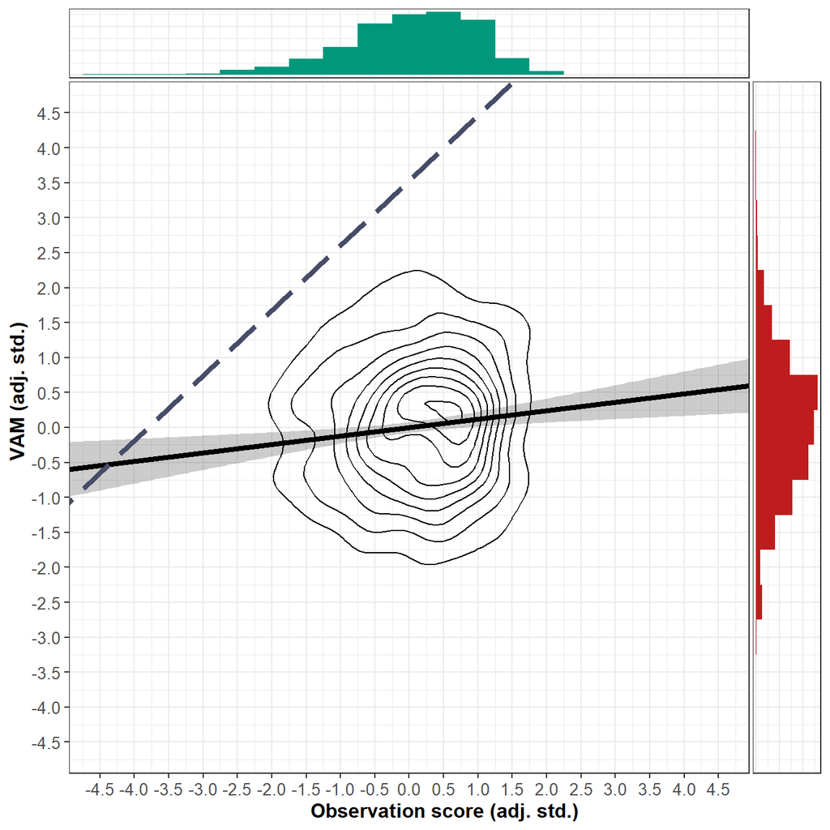

#### **Figure**

#### *NCA Plot: FFT indicators - VA_BAM_adj_std*

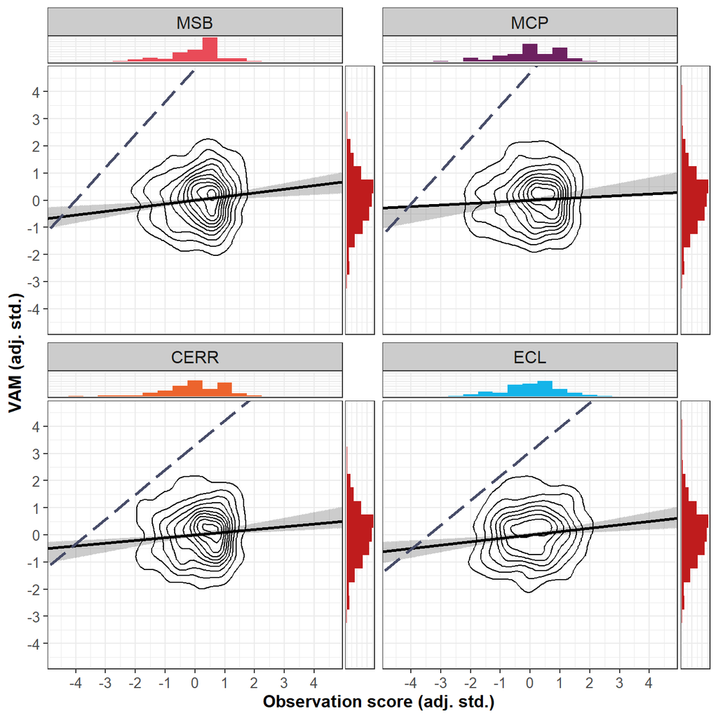

Bottlenecks (expressed as actual values)

| VA_BAM_adj_std | cr_fdh FFT_CEV_adj_std | cr_fdh FFT_MSB_adj_std | cr_fdh FFT_MCP_adj_std | cr_fdh FFT_CERR_adj_std | cr_fdh FFT_ECL_adj_std |
| --- | --- | --- | --- | --- | --- |
| -3.0 | NN | NN | NN | NN | NN |
| -2.5 | NN | NN | NN | NN | NN |
| -2.0 | NN | NN | NN | NN | NN |
| -1.5 | NN | NN | NN | NN | NN |
| -1.0 | NN | NN | -4.724 | NN | NN |
| -0.5 | -4.346 | NN | -4.310 | -4.191 | -3.968 |
| 0.0 | -3.809 | -4.016 | -3.896 | -3.641 | -3.412 |
| 0.5 | -3.271 | -3.603 | -3.483 | -3.091 | -2.857 |
| 1.0 | -2.734 | -3.190 | -3.069 | -2.541 | -2.301 |
| 1.5 | -2.196 | -2.778 | -2.655 | -1.991 | -1.746 |
| 2.0 | -1.659 | -2.365 | -2.242 | -1.441 | -1.190 |
| 2.5 | -1.122 | -1.952 | -1.828 | -0.891 | -0.634 |
| 3.0 | -0.584 | -1.540 | -1.415 | -0.340 | -0.079 |
| 3.5 | -0.047 | -1.127 | -1.001 | 0.210 | 0.477 |

Note. Data from 642 classrooms is included. NN = Not necessary.

Bottlenecks (expressed as percentage range)

| VA_BAM_adj_std | cr_fdh FFT_CEV_adj_std | cr_fdh FFT_MSB_adj_std | cr_fdh FFT_MCP_adj_std | cr_fdh FFT_CERR_adj_std | cr_fdh FFT_ECL_adj_std |
| --- | --- | --- | --- | --- | --- |
| -3.0 | NN | NN | NN | NN | NN |
| -2.5 | NN | NN | NN | NN | NN |
| -2.0 | NN | NN | NN | NN | NN |
| -1.5 | NN | NN | NN | NN | NN |
| -1.0 | NN | NN | 2.0 | NN | NN |
| -0.5 | 5.2 | NN | 7.9 | 0.4 | 1.1 |
| 0.0 | 13.2 | 2.9 | 13.7 | 9.1 | 8.9 |
| 0.5 | 21.1 | 9.4 | 19.5 | 17.8 | 16.8 |
| 1.0 | 29.1 | 15.9 | 25.4 | 26.6 | 24.6 |
| 1.5 | 37.1 | 22.4 | 31.2 | 35.3 | 32.5 |
| 2.0 | 45.0 | 28.9 | 37.1 | 44.0 | 40.3 |
| 2.5 | 53.0 | 35.3 | 42.9 | 52.7 | 48.2 |
| 3.0 | 61.0 | 41.8 | 48.8 | 61.4 | 56.1 |
| 3.5 | 69.0 | 48.3 | 54.6 | 70.1 | 63.9 |

Note. Data from 642 classrooms is included. NN = Not necessary.

Bottlenecks (expressed as percentiles)

| VA_BAM_adj_std | cr_fdh FFT_CEV_adj_std | cr_fdh FFT_MSB_adj_std | cr_fdh FFT_MCP_adj_std | cr_fdh FFT_CERR_adj_std | cr_fdh FFT_ECL_adj_std |
| --- | --- | --- | --- | --- | --- |
| -3.0 | NN | NN | NN | NN | NN |
| -2.5 | NN | NN | NN | NN | NN |
| -2.0 | NN | NN | NN | NN | NN |
| -1.5 | NN | NN | NN | NN | NN |
| -1.0 | NN | NN | 0.2 | NN | NN |
| -0.5 | 0.3 | NN | 0.2 | 0.2 | 0.2 |
| 0.0 | 0.5 | 0.2 | 0.3 | 0.5 | 0.3 |
| 0.5 | 0.6 | 0.5 | 0.3 | 0.8 | 0.5 |
| 1.0 | 1.1 | 1.6 | 1.2 | 2.0 | 1.2 |
| 1.5 | 2.6 | 1.6 | 1.2 | 4.5 | 4.4 |
| 2.0 | 5.8 | 2.5 | 1.9 | 9.2 | 12.3 |
| 2.5 | 13.2 | 5.5 | 7.8 | 18.8 | 29.6 |
| 3.0 | 24.1 | 6.5 | 9.8 | 35.0 | 51.9 |
| 3.5 | 42.5 | 13.9 | 18.5 | 53.9 | 63.1 |

Note. Data from 642 classrooms is included. NN = Not necessary.

## NCA outliers - FFT (adj.)

### State assessment in maths (adj. std.)

OLS coefficients

| Domain | Coefficient | Item | Estimate | Std. Error | t value | p value |
| --- | --- | --- | --- | --- | --- | --- |
| FFT_CEV_adj | Intercept | CEV | -2.046 | 0.556 | -3.678 | 0.000 |
| FFT_CEV_adj | Beta | CEV | 0.761 | 0.208 | 3.667 | 0.000 |
| FFT_MSB_adj | Intercept | MSB | -1.544 | 0.504 | -3.062 | 0.002 |
| FFT_MSB_adj | Beta | MSB | 0.554 | 0.182 | 3.050 | 0.002 |
| FFT_MCP_adj | Intercept | MCP | -2.248 | 0.566 | -3.969 | 0.000 |
| FFT_MCP_adj | Beta | MCP | 0.829 | 0.209 | 3.959 | 0.000 |
| FFT_CERR_adj | Intercept | CERR | -1.113 | 0.447 | -2.490 | 0.013 |
| FFT_CERR_adj | Beta | CERR | 0.411 | 0.166 | 2.475 | 0.014 |
| FFT_ECL_adj | Intercept | ECL | -1.503 | 0.440 | -3.417 | 0.001 |
| FFT_ECL_adj | Beta | ECL | 0.586 | 0.172 | 3.406 | 0.001 |
| All | Intercept |  | -2.392 | 0.587 | -4.077 | 0.000 |
| All | Beta | MSB | 0.086 | 0.302 | 0.285 | 0.776 |
| All | Beta | MCP | 0.701 | 0.329 | 2.132 | 0.033 |
| All | Beta | CERR | -0.282 | 0.280 | -1.008 | 0.314 |
| All | Beta | ECL | 0.396 | 0.251 | 1.574 | 0.116 |

Note. Data from 628 classrooms is included.

NCA parameters

| Parameter | FFT_CEV_adj cr_fdh | FFT_MSB_adj cr_fdh | FFT_MCP_adj cr_fdh | FFT_CERR_adj cr_fdh | FFT_ECL_adj cr_fdh |
| --- | --- | --- | --- | --- | --- |
| Number of observations | 628 | 628 | 628 | 628 | 628 |
| Scope | 5.619828 | 7.158641 | 5.991742 | 7.451801 | 7.75338 |
| Ceiling zone | 0.5874201 | 0.6503411 | 0.6168244 | 0.9503294 | 0.7761594 |
| Effect size | 0.1045264 | 0.09084701 | 0.1029458 | 0.1275302 | 0.1001059 |
| Slope | 4.144126 | 2.634649 | 2.946656 | 4.066546 | 3.810564 |
| Intercept | -7.978938 | -4.218685 | -5.12011 | -7.567005 | -6.740384 |
| p-value | 0.4454555 | 0.5469453 | 0.4442556 | 0.2507749 | 0.279672 |
| p-accuracy | 0.009741334 | 0.009756529 | 0.009738725 | 0.008495644 | 0.008797064 |
| Complexity | 1 | 1 | 1 | 1 | 1 |
| Fit |  | 82.1211 | 80.23205 |  |  |
| Ceiling accuracy | 99.20382 | 99.68153 | 99.20382 | 98.88535 | 98.88535 |
| Accuracy nof | 623 | 626 | 623 | 621 | 621 |
| Noise | 0.5 | 0.3 | 0.8 | 0.8 | 1 |
| Noise nof | 3 | 2 | 5 | 5 | 6 |
| Exceptions | 0.3 | 0 | 0 | 0.3 | 0.2 |
| Exceptions nof | 2 | 0 | 0 | 2 | 1 |
| Support | 2.1 | 2.1 | 2.2 | 3 | 3.7 |
| Support nof | 13 | 13 | 14 | 19 | 23 |
| Spread | 0.44 | 0.43 | 0.41 | 0.4 | 0.32 |
| Sharpness | 0.79 | 0.82 | 0.72 | 0.77 | 0.78 |
| Abs. ineff. | 4.444988 | 5.857959 | 4.758093 | 5.551142 | 6.201061 |
| Rel. ineff. | 79.09473 | 81.8306 | 79.41085 | 74.49397 | 79.97881 |
| Condition ineff. | 44.89732 | 42.91574 | 37.19405 | 46.64185 | 52.12293 |
| Outcome ineff. | 62.06124 | 68.17091 | 67.21783 | 52.19843 | 58.18209 |

Note. Data from 628 classrooms is included.  
This table was saved as coef_NCA_outliers_Y2_FFT_adj_VA_MATH_adj_std.csv

#### **Figure**

#### *NCA Plot: FFT_CEV_adj - VA_MATH_adj_std*

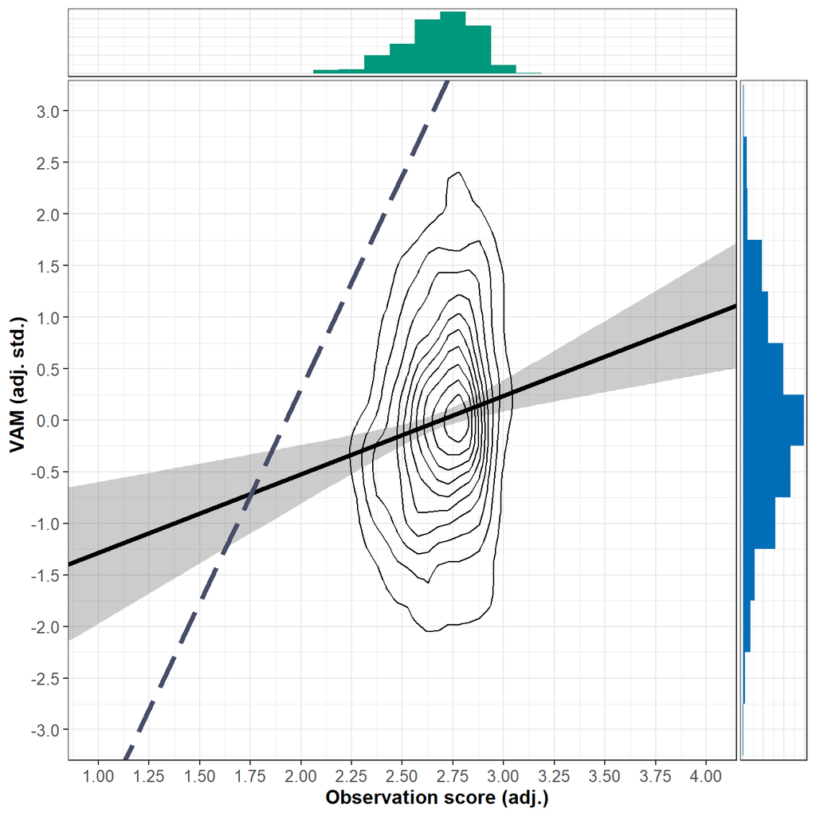

#### **Figure**

#### *NCA Plot: FFT indicators - VA_MATH_adj_std*

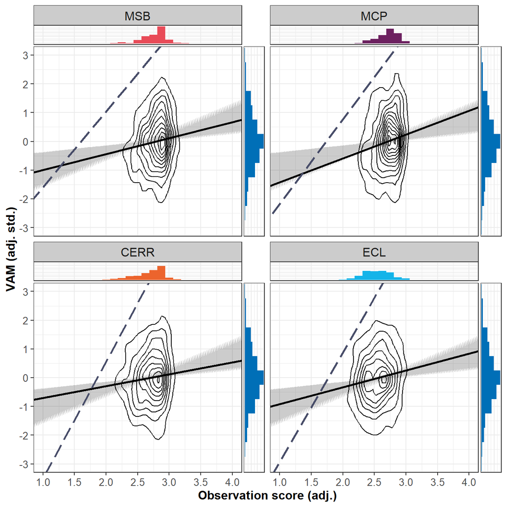

Bottlenecks (expressed as actual values)

| VA_MATH_adj_std | cr_fdh FFT_CEV_adj | cr_fdh FFT_MSB_adj | cr_fdh FFT_MCP_adj | cr_fdh FFT_CERR_adj | cr_fdh FFT_ECL_adj |
| --- | --- | --- | --- | --- | --- |
| -2.5 | NN | NN | NN | NN | NN |
| -2.0 | NN | NN | NN | NN | NN |
| -1.5 | NN | NN | NN | NN | NN |
| -1.0 | NN | NN | NN | NN | NN |
| -0.5 | NN | NN | NN | NN | NN |
| 0.0 | NN | NN | NN | NN | NN |
| 0.5 | NN | NN | NN | 1.984 | 1.900 |
| 1.0 | 2.167 | NN | NN | 2.107 | 2.031 |
| 1.5 | 2.287 | 2.171 | 2.247 | 2.230 | 2.163 |
| 2.0 | 2.408 | 2.360 | 2.416 | 2.353 | 2.294 |
| 2.5 | 2.529 | 2.550 | 2.586 | 2.476 | 2.425 |

Note. Data from 628 classrooms is included. NN = Not necessary.

Bottlenecks (expressed as percentage range)

| VA_MATH_adj_std | cr_fdh FFT_CEV_adj | cr_fdh FFT_MSB_adj | cr_fdh FFT_MCP_adj | cr_fdh FFT_CERR_adj | cr_fdh FFT_ECL_adj |
| --- | --- | --- | --- | --- | --- |
| -2.5 | NN | NN | NN | NN | NN |
| -2.0 | NN | NN | NN | NN | NN |
| -1.5 | NN | NN | NN | NN | NN |
| -1.0 | NN | NN | NN | NN | NN |
| -0.5 | NN | NN | NN | NN | NN |
| 0.0 | NN | NN | NN | NN | NN |
| 0.5 | NN | NN | NN | 6.7 | 0.0 |
| 1.0 | 6.9 | NN | NN | 16.3 | 9.9 |
| 1.5 | 19.4 | 13.0 | 15.7 | 25.9 | 19.7 |
| 2.0 | 31.9 | 28.4 | 32.2 | 35.5 | 29.6 |
| 2.5 | 44.4 | 43.8 | 48.6 | 45.1 | 39.4 |

Note. Data from 628 classrooms is included. NN = Not necessary.

Bottlenecks (expressed as percentiles)

| VA_MATH_adj_std | cr_fdh FFT_CEV_adj | cr_fdh FFT_MSB_adj | cr_fdh FFT_MCP_adj | cr_fdh FFT_CERR_adj | cr_fdh FFT_ECL_adj |
| --- | --- | --- | --- | --- | --- |
| -2.5 | NN | NN | NN | NN | NN |
| -2.0 | NN | NN | NN | NN | NN |
| -1.5 | NN | NN | NN | NN | NN |
| -1.0 | NN | NN | NN | NN | NN |
| -0.5 | NN | NN | NN | NN | NN |
| 0.0 | NN | NN | NN | NN | NN |
| 0.5 | NN | NN | NN | 1.3 | 0.2 |
| 1.0 | 1.3 | NN | NN | 1.6 | 0.6 |
| 1.5 | 3.2 | 1.6 | 1.1 | 4.0 | 4.0 |
| 2.0 | 8.9 | 4.9 | 8.9 | 8.8 | 13.1 |
| 2.5 | 19.6 | 14.0 | 21.8 | 18.3 | 33.0 |

Note. Data from 628 classrooms is included. NN = Not necessary.

### Balanced assessment of maths (adj. std.)

OLS coefficients

| Domain | Coefficient | Item | Estimate | Std. Error | t value | p value |
| --- | --- | --- | --- | --- | --- | --- |
| FFT_CEV_adj | Intercept | CEV | -1.357 | 0.559 | -2.430 | 0.015 |
| FFT_CEV_adj | Beta | CEV | 0.500 | 0.209 | 2.399 | 0.017 |
| FFT_MSB_adj | Intercept | MSB | -1.474 | 0.504 | -2.925 | 0.004 |
| FFT_MSB_adj | Beta | MSB | 0.525 | 0.182 | 2.893 | 0.004 |
| FFT_MCP_adj | Intercept | MCP | -0.575 | 0.572 | -1.005 | 0.315 |
| FFT_MCP_adj | Beta | MCP | 0.205 | 0.211 | 0.971 | 0.332 |
| FFT_CERR_adj | Intercept | CERR | -0.836 | 0.447 | -1.871 | 0.062 |
| FFT_CERR_adj | Beta | CERR | 0.305 | 0.166 | 1.832 | 0.067 |
| FFT_ECL_adj | Intercept | ECL | -1.118 | 0.441 | -2.534 | 0.012 |
| FFT_ECL_adj | Beta | ECL | 0.431 | 0.173 | 2.497 | 0.013 |
| All | Intercept |  | -1.120 | 0.588 | -1.906 | 0.057 |
| All | Beta | MSB | 0.817 | 0.303 | 2.697 | 0.007 |
| All | Beta | MCP | -0.649 | 0.329 | -1.970 | 0.049 |
| All | Beta | CERR | -0.190 | 0.280 | -0.677 | 0.499 |
| All | Beta | ECL | 0.431 | 0.252 | 1.713 | 0.087 |

Note. Data from 628 classrooms is included.

NCA parameters

| Parameter | FFT_CEV_adj cr_fdh | FFT_MSB_adj cr_fdh | FFT_MCP_adj cr_fdh | FFT_CERR_adj cr_fdh | FFT_ECL_adj cr_fdh |
| --- | --- | --- | --- | --- | --- |
| Number of observations | 628 | 628 | 628 | 628 | 628 |
| Scope | 5.470441 | 6.968349 | 5.832469 | 7.253716 | 7.547279 |
| Ceiling zone | 0.5934106 | 0.6609979 | 0.701728 | 1.033793 | 0.756349 |
| Effect size | 0.1084758 | 0.09485716 | 0.1203141 | 0.142519 | 0.1002148 |
| Slope | 3.016687 | 1.715479 | 2.582655 | 4.844469 | 2.615773 |
| Intercept | -5.452998 | -2.18123 | -4.514421 | -9.583953 | -4.183882 |
| p-value | 0.4072593 | 0.5367463 | 0.2377762 | 0.1255874 | 0.2822718 |
| p-accuracy | 0.009629771 | 0.009773319 | 0.008343986 | 0.006495004 | 0.008821894 |
| Complexity | 1 | 1 | 1 | 1 | 1 |
| Fit | 90.57945 | 86.45395 | 90.69935 | 92.9898 | 90.62497 |
| Ceiling accuracy | 99.36306 | 99.52229 | 99.20382 | 98.56688 | 99.20382 |
| Accuracy nof | 624 | 625 | 623 | 619 | 623 |
| Noise | 0.6 | 0.5 | 0.8 | 1.4 | 0.8 |
| Noise nof | 4 | 3 | 5 | 9 | 5 |
| Exceptions | 0 | 0 | 0 | 0 | 0 |
| Exceptions nof | 0 | 0 | 0 | 0 | 0 |
| Support | 4 | 1.9 | 4.9 | 6.5 | 5.3 |
| Support nof | 25 | 12 | 31 | 41 | 33 |
| Spread | 0.36 | 0.42 | 0.34 | 0.26 | 0.29 |
| Sharpness | 0.85 | 0.75 | 0.86 | 0.81 | 0.86 |
| Abs. ineff. | 4.28362 | 5.646354 | 4.429013 | 5.186131 | 6.034581 |
| Rel. ineff. | 78.30484 | 81.02857 | 75.93719 | 71.4962 | 79.95704 |
| Condition ineff. | 35.08766 | 28.67946 | 28.44567 | 49.01174 | 42.95628 |
| Outcome ineff. | 66.57775 | 73.39976 | 66.37127 | 44.09732 | 64.86387 |

Note. Data from 628 classrooms is included.  
This table was saved as coef_NCA_outliers_Y2_FFT_adj_VA_BAM_adj_std.csv

#### **Figure**

#### *NCA Plot: FFT_CEV_adj - VA_BAM_adj_std*

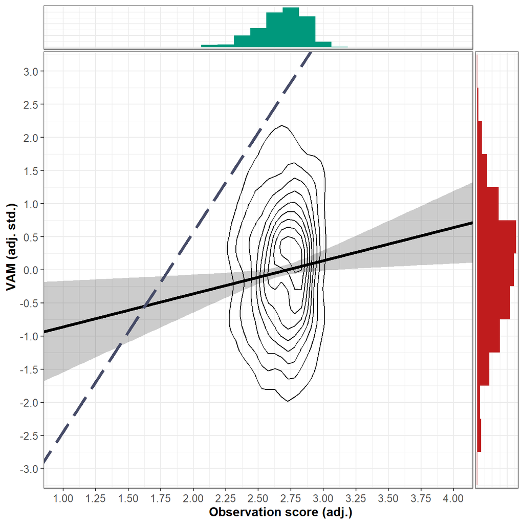

#### **Figure**

#### *NCA Plot: FFT indicators - VA_BAM_adj_std*

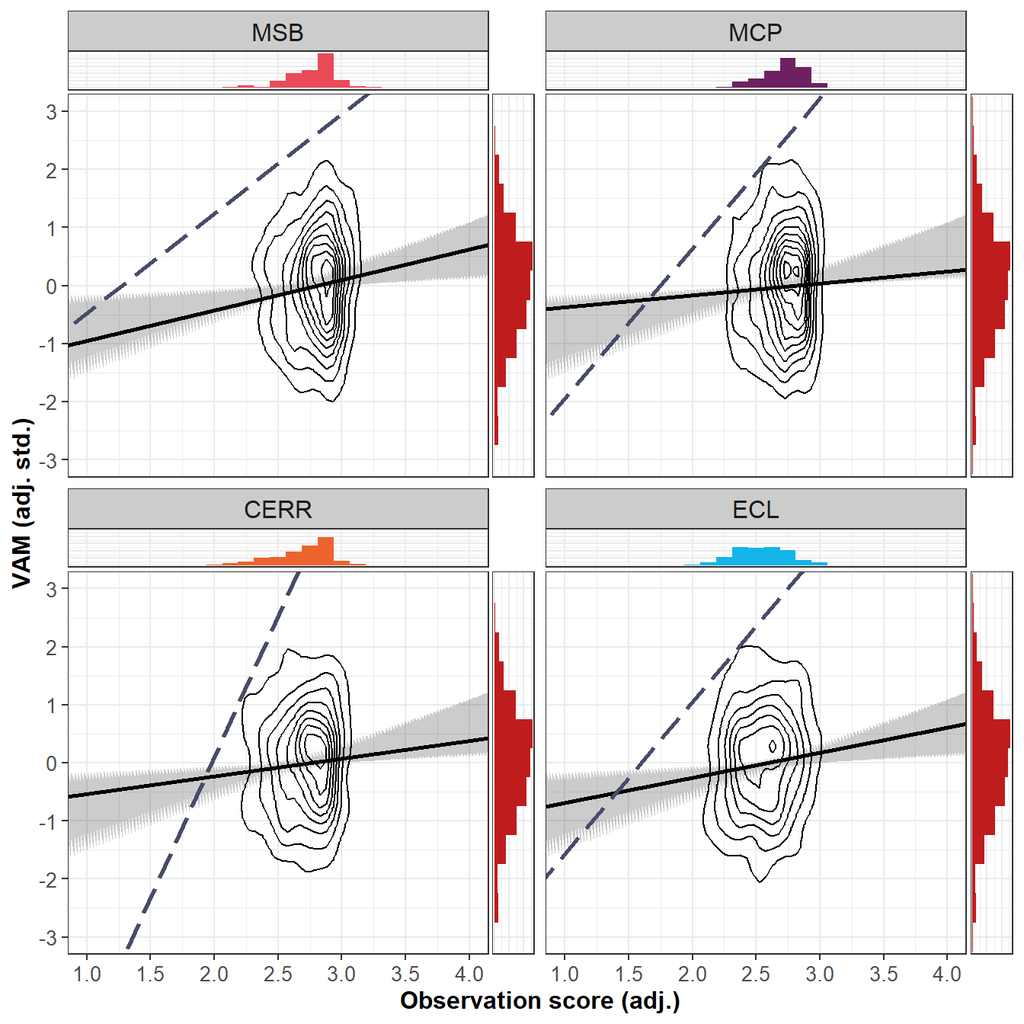

Bottlenecks (expressed as actual values)

| VA_BAM_adj_std | cr_fdh FFT_CEV_adj | cr_fdh FFT_MSB_adj | cr_fdh FFT_MCP_adj | cr_fdh FFT_CERR_adj | cr_fdh FFT_ECL_adj |
| --- | --- | --- | --- | --- | --- |
| -2.5 | NN | NN | NN | NN | NN |
| -2.0 | NN | NN | NN | NN | NN |
| -1.5 | NN | NN | NN | NN | NN |
| -1.0 | NN | NN | NN | NN | NN |
| -0.5 | NN | NN | NN | NN | NN |
| 0.0 | NN | NN | NN | 1.978 | NN |
| 0.5 | NN | NN | NN | 2.082 | NN |
| 1.0 | 2.139 | NN | 2.135 | 2.185 | 1.982 |
| 1.5 | 2.305 | 2.146 | 2.329 | 2.288 | 2.173 |
| 2.0 | 2.471 | 2.437 | 2.522 | 2.391 | 2.364 |
| 2.5 | 2.636 | 2.729 | 2.716 | 2.494 | 2.555 |

Note. Data from 628 classrooms is included. NN = Not necessary.

Bottlenecks (expressed as percentage range)

| VA_BAM_adj_std | cr_fdh FFT_CEV_adj | cr_fdh FFT_MSB_adj | cr_fdh FFT_MCP_adj | cr_fdh FFT_CERR_adj | cr_fdh FFT_ECL_adj |
| --- | --- | --- | --- | --- | --- |
| -2.5 | NN | NN | NN | NN | NN |
| -2.0 | NN | NN | NN | NN | NN |
| -1.5 | NN | NN | NN | NN | NN |
| -1.0 | NN | NN | NN | NN | NN |
| -0.5 | NN | NN | NN | NN | NN |
| 0.0 | NN | NN | NN | 6.3 | NN |
| 0.5 | NN | NN | NN | 14.4 | NN |
| 1.0 | 4.1 | NN | 4.9 | 22.4 | 6.2 |
| 1.5 | 21.2 | 11.0 | 23.7 | 30.5 | 20.5 |
| 2.0 | 38.4 | 34.7 | 42.5 | 38.5 | 34.8 |
| 2.5 | 55.5 | 58.3 | 61.3 | 46.6 | 49.2 |

Note. Data from 628 classrooms is included. NN = Not necessary.

Bottlenecks (expressed as percentiles)

| VA_BAM_adj_std | cr_fdh FFT_CEV_adj | cr_fdh FFT_MSB_adj | cr_fdh FFT_MCP_adj | cr_fdh FFT_CERR_adj | cr_fdh FFT_ECL_adj |
| --- | --- | --- | --- | --- | --- |
| -2.5 | NN | NN | NN | NN | NN |
| -2.0 | NN | NN | NN | NN | NN |
| -1.5 | NN | NN | NN | NN | NN |
| -1.0 | NN | NN | NN | NN | NN |
| -0.5 | NN | NN | NN | NN | NN |
| 0.0 | NN | NN | NN | 1.3 | NN |
| 0.5 | NN | NN | NN | 1.3 | NN |
| 1.0 | 0.8 | NN | 0.5 | 3.3 | 0.6 |
| 1.5 | 3.3 | 0.8 | 2.1 | 7.8 | 4.0 |
| 2.0 | 15.4 | 5.9 | 18.5 | 10.0 | 16.7 |
| 2.5 | 37.7 | 31.1 | 39.6 | 19.4 | 51.9 |

Note. Data from 628 classrooms is included. NN = Not necessary.

## NCA outliers - FFT (adj. std.)

### State assessment in maths (adj. std.)

OLS coefficients

| Domain | Coefficient | Item | Estimate | Std. Error | t value | p value |
| --- | --- | --- | --- | --- | --- | --- |
| FFT_CEV_adj_std | Intercept | CEV | -0.015 | 0.038 | -0.390 | 0.696 |
| FFT_CEV_adj_std | Beta | CEV | 0.148 | 0.040 | 3.667 | 0.000 |
| FFT_MSB_adj_std | Intercept | MSB | -0.014 | 0.038 | -0.359 | 0.720 |
| FFT_MSB_adj_std | Beta | MSB | 0.123 | 0.040 | 3.050 | 0.002 |
| FFT_MCP_adj_std | Intercept | MCP | -0.015 | 0.038 | -0.402 | 0.688 |
| FFT_MCP_adj_std | Beta | MCP | 0.158 | 0.040 | 3.959 | 0.000 |
| FFT_CERR_adj_std | Intercept | CERR | -0.013 | 0.038 | -0.350 | 0.727 |
| FFT_CERR_adj_std | Beta | CERR | 0.100 | 0.040 | 2.475 | 0.014 |
| FFT_ECL_adj_std | Intercept | ECL | -0.013 | 0.038 | -0.347 | 0.729 |
| FFT_ECL_adj_std | Beta | ECL | 0.134 | 0.039 | 3.406 | 0.001 |
| All | Intercept |  | -0.015 | 0.038 | -0.392 | 0.695 |
| All | Beta | MSB | 0.019 | 0.067 | 0.285 | 0.776 |
| All | Beta | MCP | 0.134 | 0.063 | 2.132 | 0.033 |
| All | Beta | CERR | -0.068 | 0.068 | -1.008 | 0.314 |
| All | Beta | ECL | 0.090 | 0.057 | 1.574 | 0.116 |

Note. Data from 628 classrooms is included.

NCA parameters

| Parameter | FFT_CEV_adj_std cr_fdh | FFT_MSB_adj_std cr_fdh | FFT_MCP_adj_std cr_fdh | FFT_CERR_adj_std cr_fdh | FFT_ECL_adj_std cr_fdh |
| --- | --- | --- | --- | --- | --- |
| Number of observations | 628 | 628 | 628 | 628 | 628 |
| Scope | 28.82316 | 32.27666 | 31.37737 | 30.79707 | 33.95747 |
| Ceiling zone | 3.01278 | 2.932238 | 3.230167 | 3.927556 | 3.399344 |
| Effect size | 0.1045264 | 0.09084701 | 0.1029458 | 0.1275302 | 0.1001059 |
| Slope | 0.8080055 | 0.5843389 | 0.5626858 | 0.9839601 | 0.8700516 |
| Intercept | 3.074093 | 3.059364 | 2.814245 | 3.300099 | 2.94305 |
| p-value | 0.4490551 | 0.5637436 | 0.460454 | 0.2407759 | 0.2671733 |
| p-accuracy | 0.009748819 | 0.009719855 | 0.00976912 | 0.008379915 | 0.008672519 |
| Complexity | 1 | 1 | 1 | 1 | 1 |
| Fit |  | 82.1211 | 80.23205 |  |  |
| Ceiling accuracy | 99.20382 | 99.68153 | 99.20382 | 98.88535 | 98.88535 |
| Accuracy nof | 623 | 626 | 623 | 621 | 621 |
| Noise | 0.5 | 0.3 | 0.8 | 0.8 | 1 |
| Noise nof | 3 | 2 | 5 | 5 | 6 |
| Exceptions | 0.3 | 0 | 0 | 0.3 | 0.2 |
| Exceptions nof | 2 | 0 | 0 | 2 | 1 |
| Support | 2.1 | 2.1 | 2.2 | 3 | 3.7 |
| Support nof | 13 | 13 | 14 | 19 | 23 |
| Spread | 0.44 | 0.43 | 0.41 | 0.4 | 0.32 |
| Sharpness | 0.79 | 0.82 | 0.72 | 0.77 | 0.78 |
| Abs. ineff. | 22.7976 | 26.41218 | 24.91704 | 22.94196 | 27.15878 |
| Rel. ineff. | 79.09473 | 81.8306 | 79.41085 | 74.49397 | 79.97881 |
| Condition ineff. | 44.89732 | 42.91574 | 37.19405 | 46.64185 | 52.12293 |
| Outcome ineff. | 62.06124 | 68.17091 | 67.21783 | 52.19843 | 58.18209 |

Note. Data from 628 classrooms is included.  
This table was saved as coef_NCA_outliers_Y2_FFT_adj_std_VA_MATH_adj_std.csv

#### **Figure**

#### *NCA Plot: FFT_CEV_adj_std - VA_MATH_adj_std*

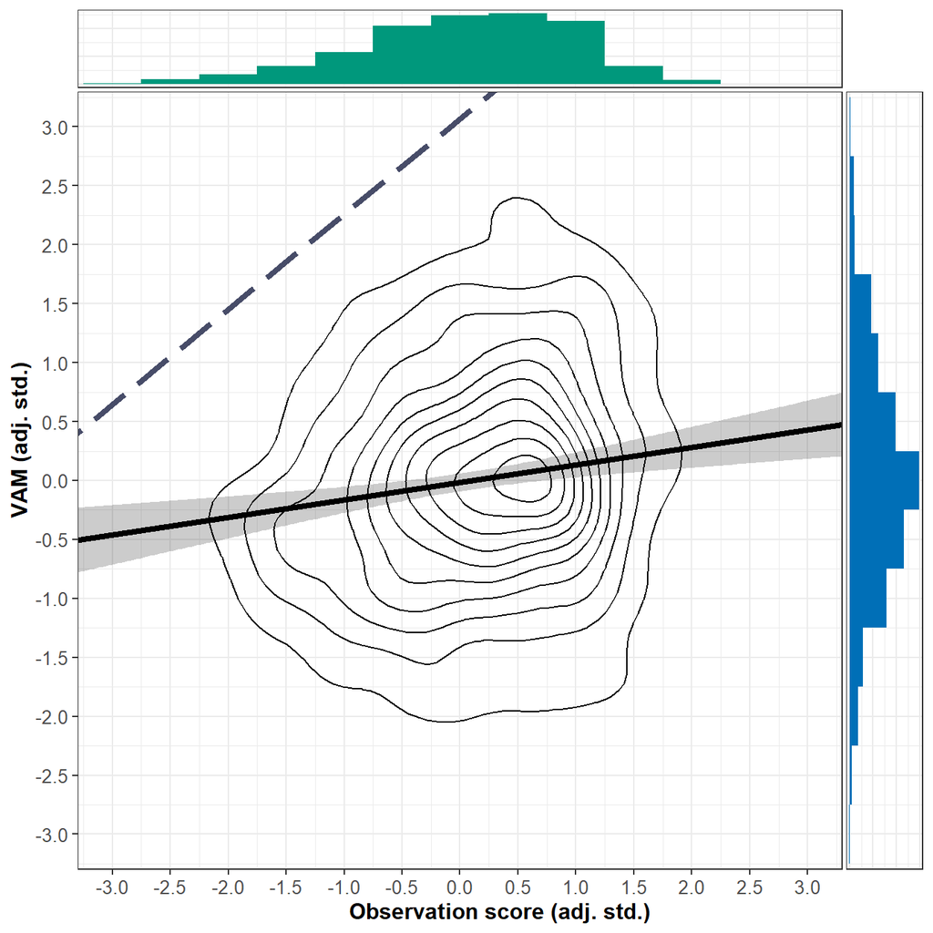

#### **Figure**

#### *NCA Plot: FFT indicators - VA_MATH_adj_std*

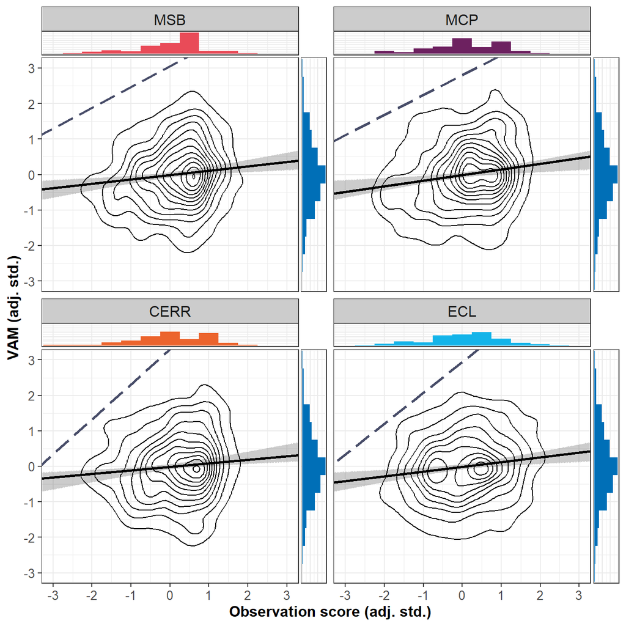

Bottlenecks (expressed as actual values)

| VA_MATH_adj_std | cr_fdh FFT_CEV_adj_std | cr_fdh FFT_MSB_adj_std | cr_fdh FFT_MCP_adj_std | cr_fdh FFT_CERR_adj_std | cr_fdh FFT_ECL_adj_std |
| --- | --- | --- | --- | --- | --- |
| -2.5 | NN | NN | NN | NN | NN |
| -2.0 | NN | NN | NN | NN | NN |
| -1.5 | NN | NN | NN | NN | NN |
| -1.0 | NN | NN | NN | NN | NN |
| -0.5 | NN | NN | NN | NN | NN |
| 0.0 | NN | NN | NN | NN | NN |
| 0.5 | NN | NN | NN | -2.846 | -2.808 |
| 1.0 | -2.567 | NN | NN | -2.338 | -2.233 |
| 1.5 | -1.948 | -2.669 | -2.336 | -1.829 | -1.659 |
| 2.0 | -1.329 | -1.813 | -1.447 | -1.321 | -1.084 |
| 2.5 | -0.711 | -0.957 | -0.558 | -0.813 | -0.509 |

Note. Data from 628 classrooms is included. NN = Not necessary.

Bottlenecks (expressed as percentage range)

| VA_MATH_adj_std | cr_fdh FFT_CEV_adj_std | cr_fdh FFT_MSB_adj_std | cr_fdh FFT_MCP_adj_std | cr_fdh FFT_CERR_adj_std | cr_fdh FFT_ECL_adj_std |
| --- | --- | --- | --- | --- | --- |
| -2.5 | NN | NN | NN | NN | NN |
| -2.0 | NN | NN | NN | NN | NN |
| -1.5 | NN | NN | NN | NN | NN |
| -1.0 | NN | NN | NN | NN | NN |
| -0.5 | NN | NN | NN | NN | NN |
| 0.0 | NN | NN | NN | NN | NN |
| 0.5 | NN | NN | NN | 6.7 | 0.0 |
| 1.0 | 6.9 | NN | NN | 16.3 | 9.9 |
| 1.5 | 19.4 | 13.0 | 15.7 | 25.9 | 19.7 |
| 2.0 | 31.9 | 28.4 | 32.2 | 35.5 | 29.6 |
| 2.5 | 44.4 | 43.8 | 48.6 | 45.1 | 39.4 |

Note. Data from 628 classrooms is included. NN = Not necessary.

Bottlenecks (expressed as percentiles)

| VA_MATH_adj_std | cr_fdh FFT_CEV_adj_std | cr_fdh FFT_MSB_adj_std | cr_fdh FFT_MCP_adj_std | cr_fdh FFT_CERR_adj_std | cr_fdh FFT_ECL_adj_std |
| --- | --- | --- | --- | --- | --- |
| -2.5 | NN | NN | NN | NN | NN |
| -2.0 | NN | NN | NN | NN | NN |
| -1.5 | NN | NN | NN | NN | NN |
| -1.0 | NN | NN | NN | NN | NN |
| -0.5 | NN | NN | NN | NN | NN |
| 0.0 | NN | NN | NN | NN | NN |
| 0.5 | NN | NN | NN | 1.3 | 0.2 |
| 1.0 | 1.3 | NN | NN | 1.6 | 0.6 |
| 1.5 | 3.2 | 1.6 | 1.1 | 4.0 | 4.0 |
| 2.0 | 8.9 | 4.9 | 8.9 | 8.8 | 13.1 |
| 2.5 | 19.6 | 14.0 | 21.8 | 18.3 | 33.0 |

Note. Data from 628 classrooms is included. NN = Not necessary.

### Balanced assessment of maths (adj. std.)

OLS coefficients

| Domain | Coefficient | Item | Estimate | Std. Error | t value | p value |
| --- | --- | --- | --- | --- | --- | --- |
| FFT_CEV_adj_std | Intercept | CEV | -0.023 | 0.038 | -0.610 | 0.542 |
| FFT_CEV_adj_std | Beta | CEV | 0.098 | 0.041 | 2.399 | 0.017 |
| FFT_MSB_adj_std | Intercept | MSB | -0.023 | 0.038 | -0.615 | 0.539 |
| FFT_MSB_adj_std | Beta | MSB | 0.116 | 0.040 | 2.893 | 0.004 |
| FFT_MCP_adj_std | Intercept | MCP | -0.022 | 0.038 | -0.566 | 0.571 |
| FFT_MCP_adj_std | Beta | MCP | 0.039 | 0.040 | 0.971 | 0.332 |
| FFT_CERR_adj_std | Intercept | CERR | -0.022 | 0.038 | -0.590 | 0.556 |
| FFT_CERR_adj_std | Beta | CERR | 0.074 | 0.040 | 1.832 | 0.067 |
| FFT_ECL_adj_std | Intercept | ECL | -0.022 | 0.038 | -0.588 | 0.557 |
| FFT_ECL_adj_std | Beta | ECL | 0.098 | 0.039 | 2.497 | 0.013 |
| All | Intercept |  | -0.022 | 0.038 | -0.580 | 0.562 |
| All | Beta | MSB | 0.181 | 0.067 | 2.697 | 0.007 |
| All | Beta | MCP | -0.124 | 0.063 | -1.970 | 0.049 |
| All | Beta | CERR | -0.046 | 0.068 | -0.677 | 0.499 |
| All | Beta | ECL | 0.099 | 0.057 | 1.713 | 0.087 |

Note. Data from 628 classrooms is included.

NCA parameters

| Parameter | FFT_CEV_adj_std cr_fdh | FFT_MSB_adj_std cr_fdh | FFT_MCP_adj_std cr_fdh | FFT_CERR_adj_std cr_fdh | FFT_ECL_adj_std cr_fdh |
| --- | --- | --- | --- | --- | --- |
| Number of observations | 628 | 628 | 628 | 628 | 628 |
| Scope | 28.05698 | 31.41868 | 30.54329 | 29.97842 | 33.05481 |
| Ceiling zone | 3.043504 | 2.980287 | 3.674788 | 4.272495 | 3.312581 |
| Effect size | 0.1084758 | 0.09485716 | 0.1203141 | 0.142519 | 0.1002148 |
| Slope | 0.588182 | 0.380476 | 0.4931771 | 1.17219 | 0.5972495 |
| Intercept | 2.592979 | 2.557669 | 2.439801 | 3.362009 | 2.463341 |
| p-value | 0.4226577 | 0.5264474 | 0.2511749 | 0.1331867 | 0.2828717 |
| p-accuracy | 0.009681868 | 0.009786101 | 0.008500146 | 0.006659495 | 0.008827572 |
| Complexity | 1 | 1 | 1 | 1 | 1 |
| Fit | 90.57945 | 86.45395 | 90.69935 | 92.9898 | 90.62497 |
| Ceiling accuracy | 99.36306 | 99.52229 | 99.20382 | 98.56688 | 99.20382 |
| Accuracy nof | 624 | 625 | 623 | 619 | 623 |
| Noise | 0.6 | 0.5 | 0.8 | 1.4 | 0.8 |
| Noise nof | 4 | 3 | 5 | 9 | 5 |
| Exceptions | 0 | 0 | 0 | 0 | 0 |
| Exceptions nof | 0 | 0 | 0 | 0 | 0 |
| Support | 4 | 1.9 | 4.9 | 6.5 | 5.3 |
| Support nof | 25 | 12 | 31 | 41 | 33 |
| Spread | 0.36 | 0.42 | 0.34 | 0.26 | 0.29 |
| Sharpness | 0.85 | 0.75 | 0.86 | 0.81 | 0.86 |
| Abs. ineff. | 21.96998 | 25.45811 | 23.19372 | 21.43343 | 26.42965 |
| Rel. ineff. | 78.30484 | 81.02857 | 75.93719 | 71.4962 | 79.95704 |
| Condition ineff. | 35.08766 | 28.67946 | 28.44567 | 49.01174 | 42.95628 |
| Outcome ineff. | 66.57775 | 73.39976 | 66.37127 | 44.09732 | 64.86387 |

Note. Data from 628 classrooms is included.  
This table was saved as coef_NCA_outliers_Y2_FFT_adj_std_VA_BAM_adj_std.csv

#### **Figure**

#### *NCA Plot: FFT_CEV_adj_std - VA_BAM_adj_std*

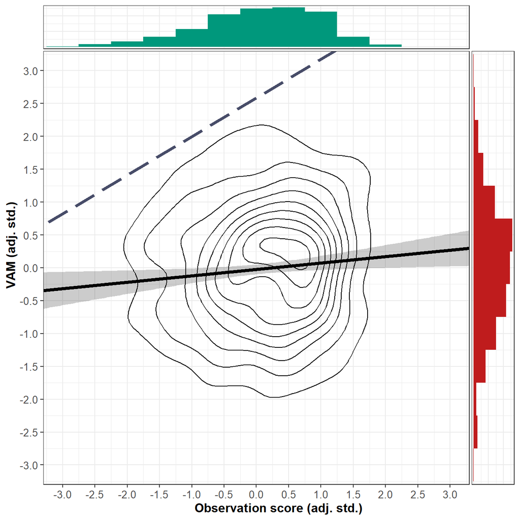

#### **Figure**

#### *NCA Plot: FFT indicators - VA_BAM_adj_std*

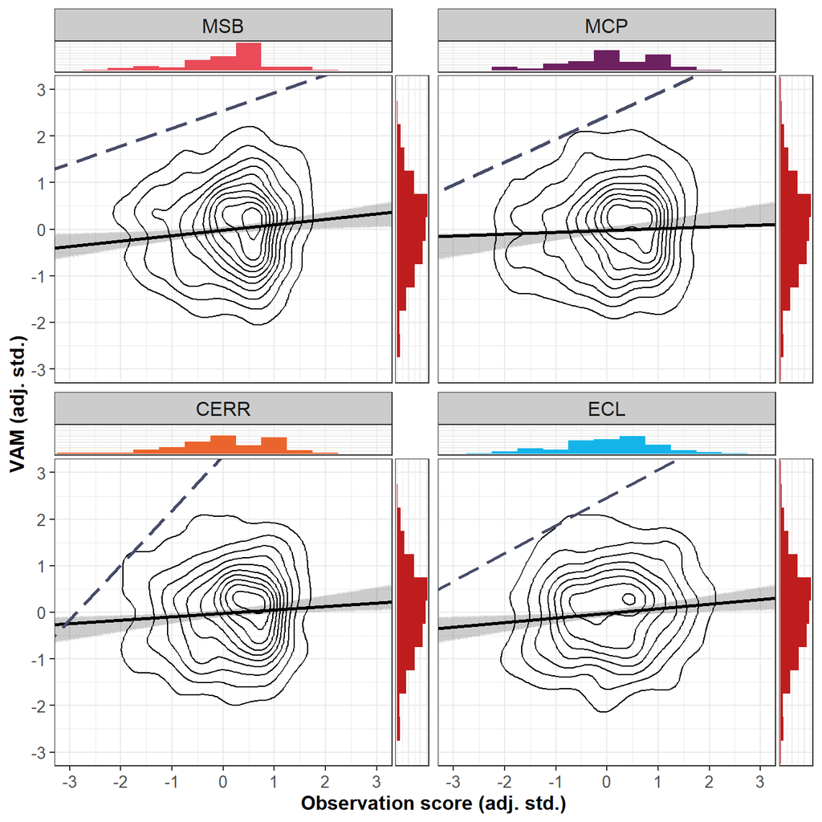

Bottlenecks (expressed as actual values)

| VA_BAM_adj_std | cr_fdh FFT_CEV_adj_std | cr_fdh FFT_MSB_adj_std | cr_fdh FFT_MCP_adj_std | cr_fdh FFT_CERR_adj_std | cr_fdh FFT_ECL_adj_std |
| --- | --- | --- | --- | --- | --- |
| -2.5 | NN | NN | NN | NN | NN |
| -2.0 | NN | NN | NN | NN | NN |
| -1.5 | NN | NN | NN | NN | NN |
| -1.0 | NN | NN | NN | NN | NN |
| -0.5 | NN | NN | NN | NN | NN |
| 0.0 | NN | NN | NN | -2.868 | NN |
| 0.5 | NN | NN | NN | -2.442 | NN |
| 1.0 | -2.708 | NN | -2.919 | -2.015 | -2.450 |
| 1.5 | -1.858 | -2.780 | -1.906 | -1.588 | -1.613 |
| 2.0 | -1.008 | -1.466 | -0.892 | -1.162 | -0.776 |
| 2.5 | -0.158 | -0.152 | 0.122 | -0.735 | 0.061 |

Note. Data from 628 classrooms is included. NN = Not necessary.

Bottlenecks (expressed as percentage range)

| VA_BAM_adj_std | cr_fdh FFT_CEV_adj_std | cr_fdh FFT_MSB_adj_std | cr_fdh FFT_MCP_adj_std | cr_fdh FFT_CERR_adj_std | cr_fdh FFT_ECL_adj_std |
| --- | --- | --- | --- | --- | --- |
| -2.5 | NN | NN | NN | NN | NN |
| -2.0 | NN | NN | NN | NN | NN |
| -1.5 | NN | NN | NN | NN | NN |
| -1.0 | NN | NN | NN | NN | NN |
| -0.5 | NN | NN | NN | NN | NN |
| 0.0 | NN | NN | NN | 6.3 | NN |
| 0.5 | NN | NN | NN | 14.4 | NN |
| 1.0 | 4.1 | NN | 4.9 | 22.4 | 6.2 |
| 1.5 | 21.2 | 11.0 | 23.7 | 30.5 | 20.5 |
| 2.0 | 38.4 | 34.7 | 42.5 | 38.5 | 34.8 |
| 2.5 | 55.5 | 58.3 | 61.3 | 46.6 | 49.2 |

Note. Data from 628 classrooms is included. NN = Not necessary.

Bottlenecks (expressed as percentiles)

| VA_BAM_adj_std | cr_fdh FFT_CEV_adj_std | cr_fdh FFT_MSB_adj_std | cr_fdh FFT_MCP_adj_std | cr_fdh FFT_CERR_adj_std | cr_fdh FFT_ECL_adj_std |
| --- | --- | --- | --- | --- | --- |
| -2.5 | NN | NN | NN | NN | NN |
| -2.0 | NN | NN | NN | NN | NN |
| -1.5 | NN | NN | NN | NN | NN |
| -1.0 | NN | NN | NN | NN | NN |
| -0.5 | NN | NN | NN | NN | NN |
| 0.0 | NN | NN | NN | 1.3 | NN |
| 0.5 | NN | NN | NN | 1.3 | NN |
| 1.0 | 0.8 | NN | 0.5 | 3.3 | 0.6 |
| 1.5 | 3.3 | 0.8 | 2.1 | 7.8 | 4.0 |
| 2.0 | 15.4 | 5.9 | 18.5 | 10.0 | 16.7 |
| 2.5 | 37.7 | 31.1 | 39.6 | 19.4 | 51.9 |

Note. Data from 628 classrooms is included. NN = Not necessary.

## Regression

OLS coefficients - Peer model

| Observation score | Model 1 B | Model 1 SE | Model 1 β | Model 1 t | Model 1 p | Model 1 N | Model 2 B | Model 2 SE | Model 2 β | Model 2 t | Model 2 p | Model 2 N |
| --- | --- | --- | --- | --- | --- | --- | --- | --- | --- | --- | --- | --- |
| VA_MATH_adj_std |  |  |  |  |  |  |  |  |  |  |  |  |
| Intercept | -1.57 | 1.22 | 0.00 | -1.286 | 0.199 | 642 | -1.41 | 1.19 | -0.02 | -1.181 | 0.238 | 631 |
| MQI_EI | -0.60 | 0.55 | -0.04 | -1.096 | 0.273 | 642 | -0.48 | 0.53 | -0.03 | -0.907 | 0.365 | 631 |
| MQI_SPMMR | -0.11 | 0.55 | -0.01 | -0.197 | 0.844 | 642 | 0.12 | 0.53 | 0.01 | 0.232 | 0.817 | 631 |
| MQI_RICH | 0.54 | 0.58 | 0.04 | 0.933 | 0.351 | 642 | 0.13 | 0.56 | 0.01 | 0.237 | 0.812 | 631 |
| MQI_WWSM | 1.40 | 0.77 | 0.08 | 1.826 | 0.068 | 642 | 1.31 | 0.75 | 0.08 | 1.759 | 0.079 | 631 |
| VA_BAM_adj_std |  |  |  |  |  |  |  |  |  |  |  |  |
| Intercept | 0.78 | 1.23 | 0.00 | 0.638 | 0.523 | 642 | 0.44 | 1.22 | -0.02 | 0.359 | 0.720 | 633 |
| MQI_EI | -0.61 | 0.55 | -0.04 | -1.104 | 0.270 | 642 | -0.65 | 0.54 | -0.05 | -1.203 | 0.229 | 633 |
| MQI_SPMMR | 0.09 | 0.55 | 0.01 | 0.162 | 0.872 | 642 | 0.00 | 0.54 | 0.00 | -0.001 | 1.000 | 633 |
| MQI_RICH | -0.21 | 0.58 | -0.02 | -0.358 | 0.720 | 642 | 0.07 | 0.57 | 0.01 | 0.123 | 0.902 | 633 |
| MQI_WWSM | 0.09 | 0.77 | 0.01 | 0.117 | 0.907 | 642 | 0.20 | 0.77 | 0.01 | 0.268 | 0.789 | 633 |

Note. In model 1, data from 642 classrooms is included. In model 2, data from peers were omitted.  
This table was saved as coef_mqi_peers.csv

OLS coefficients - outcome and/or NC threshold

| Observation score | Model 1 B | Model 1 SE | Model 1 β | Model 1 t | Model 1 p | Model 1 N | Model 2 B | Model 2 SE | Model 2 β | Model 2 t | Model 2 p | Model 2 N |
| --- | --- | --- | --- | --- | --- | --- | --- | --- | --- | --- | --- | --- |
| VA_MATH_adj_std |  |  |  |  |  |  |  |  |  |  |  |  |
| Intercept | -1.57 | 1.22 | 0.00 | -1.286 | 0.199 | 642 | 0.97 | 1.80 | 1.60 | 0.536 | 0.593 | 98 |
| MQI_EI | -0.60 | 0.55 | -0.04 | -1.096 | 0.273 | 642 | -0.40 | 0.81 | -0.03 | -0.494 | 0.623 | 98 |
| MQI_SPMMR | -0.11 | 0.55 | -0.01 | -0.197 | 0.844 | 642 | -0.90 | 0.78 | -0.08 | -1.160 | 0.249 | 98 |
| MQI_RICH | 0.54 | 0.58 | 0.04 | 0.933 | 0.351 | 642 | 0.78 | 0.70 | 0.06 | 1.118 | 0.266 | 98 |
| MQI_WWSM | 1.40 | 0.77 | 0.08 | 1.826 | 0.068 | 642 | 0.97 | 1.12 | 0.06 | 0.866 | 0.389 | 98 |
| VA_BAM_adj_std |  |  |  |  |  |  |  |  |  |  |  |  |
| Intercept | 0.78 | 1.23 | 0.00 | 0.638 | 0.523 | 642 | 0.30 | 1.64 | 1.57 | 0.184 | 0.854 | 95 |
| MQI_EI | -0.61 | 0.55 | -0.04 | -1.104 | 0.270 | 642 | 2.07 | 0.85 | 0.15 | 2.448 | 0.016 | 95 |
| MQI_SPMMR | 0.09 | 0.55 | 0.01 | 0.162 | 0.872 | 642 | 0.18 | 0.71 | 0.02 | 0.255 | 0.799 | 95 |
| MQI_RICH | -0.21 | 0.58 | -0.02 | -0.358 | 0.720 | 642 | 0.01 | 0.72 | 0.00 | 0.014 | 0.989 | 95 |
| MQI_WWSM | 0.09 | 0.77 | 0.01 | 0.117 | 0.907 | 642 | -1.19 | 1.03 | -0.07 | -1.156 | 0.251 | 95 |

Note. In model 1, data from 642 classrooms is included. In model 2, data from classrooms is included after classrooms not meeting outcome and/or NC threshold were excluded.  
This table was saved as coef_mqi_nc.csv

OLS coefficients - Inefficiency models

| Observation score | Model 1 B | Model 1 SE | Model 1 β | Model 1 t | Model 1 p | Model 1 N | Model 2 B | Model 2 SE | Model 2 β | Model 2 t | Model 2 p | Model 2 N | Model 3 B | Model 3 SE | Model 3 β | Model 3 t | Model 3 p | Model 3 N | Model 3A B | Model 3A SE | Model 3A β | Model 3A t | Model 3A p | Model 3A N | Model 3B B | Model 3B SE | Model 3B β | Model 3B t | Model 3B p | … |
| --- | --- | --- | --- | --- | --- | --- | --- | --- | --- | --- | --- | --- | --- | --- | --- | --- | --- | --- | --- | --- | --- | --- | --- | --- | --- | --- | --- | --- | --- | --- |
| VA_MATH_adj_std |  |  |  |  |  |  |  |  |  |  |  |  |  |  |  |  |  |  |  |  |  |  |  |  |  |  |  |  |  | … |
| Intercept | -1.57 | 1.22 | 0.00 | -1.286 | 0.199 | 642 | 0.88 | 1.42 | 0.18 | 0.624 | 0.533 | 291 | -5.28 | 1.90 | -0.20 | -2.787 | 0.006 | 344 | -3.74 | 2.01 | 0.11 | -1.864 | 0.063 | 277 | -3.61 | 1.69 | -1.45 | -2.140 | 0.035 | … |
| MQI_EI | -0.60 | 0.55 | -0.04 | -1.096 | 0.273 | 642 | -0.54 | 0.60 | -0.04 | -0.899 | 0.370 | 291 | -0.11 | 0.86 | -0.01 | -0.134 | 0.894 | 344 | 0.55 | 0.93 | 0.04 | 0.592 | 0.554 | 277 | -0.02 | 0.64 | 0.00 | -0.029 | 0.977 | … |
| MQI_SPMMR | -0.11 | 0.55 | -0.01 | -0.197 | 0.844 | 642 | 1.01 | 0.67 | 0.09 | 1.504 | 0.134 | 291 | -0.28 | 0.81 | -0.02 | -0.338 | 0.735 | 344 | -0.78 | 0.88 | -0.07 | -0.896 | 0.371 | 277 | -0.30 | 0.65 | -0.03 | -0.462 | 0.645 | … |
| MQI_RICH | 0.54 | 0.58 | 0.04 | 0.933 | 0.351 | 642 | -0.10 | 0.70 | -0.01 | -0.140 | 0.889 | 291 | 1.86 | 0.86 | 0.14 | 2.174 | 0.030 | 344 | 1.06 | 0.86 | 0.08 | 1.235 | 0.218 | 277 | 0.32 | 0.88 | 0.02 | 0.360 | 0.719 | … |
| MQI_WWSM | 1.40 | 0.77 | 0.08 | 1.826 | 0.068 | 642 | -0.88 | 0.84 | -0.05 | -1.048 | 0.295 | 291 | 2.56 | 1.20 | 0.15 | 2.137 | 0.033 | 344 | 2.21 | 1.24 | 0.13 | 1.772 | 0.078 | 277 | 1.70 | 1.10 | 0.10 | 1.545 | 0.125 | … |
| VA_BAM_adj_std |  |  |  |  |  |  |  |  |  |  |  |  |  |  |  |  |  |  |  |  |  |  |  |  |  |  |  |  |  | … |
| Intercept | 0.78 | 1.23 | 0.00 | 0.638 | 0.523 | 642 | 1.01 | 1.40 | 0.29 | 0.721 | 0.471 | 280 | -1.03 | 1.84 | -0.27 | -0.561 | 0.575 | 357 | 0.65 | 1.97 | 0.07 | 0.331 | 0.741 | 279 | 1.57 | 1.46 | -1.41 | 1.080 | 0.283 | … |
| MQI_EI | -0.61 | 0.55 | -0.04 | -1.104 | 0.270 | 642 | -0.37 | 0.57 | -0.03 | -0.650 | 0.516 | 280 | -0.73 | 0.84 | -0.05 | -0.868 | 0.386 | 357 | -0.54 | 0.92 | -0.04 | -0.588 | 0.557 | 279 | -1.83 | 0.62 | -0.13 | -2.947 | 0.004 | … |
| MQI_SPMMR | 0.09 | 0.55 | 0.01 | 0.162 | 0.872 | 642 | 0.47 | 0.60 | 0.04 | 0.781 | 0.435 | 280 | 0.37 | 0.83 | 0.03 | 0.441 | 0.659 | 357 | -0.43 | 0.86 | -0.04 | -0.493 | 0.623 | 279 | -0.57 | 0.67 | -0.05 | -0.842 | 0.401 | … |
| MQI_RICH | -0.21 | 0.58 | -0.02 | -0.358 | 0.720 | 642 | -1.21 | 0.68 | -0.09 | -1.786 | 0.075 | 280 | 1.66 | 0.84 | 0.12 | 1.992 | 0.047 | 357 | 0.37 | 0.85 | 0.03 | 0.433 | 0.665 | 279 | 0.22 | 0.73 | 0.02 | 0.298 | 0.766 | … |
| MQI_WWSM | 0.09 | 0.77 | 0.01 | 0.117 | 0.907 | 642 | 0.54 | 0.82 | 0.03 | 0.660 | 0.510 | 280 | -0.67 | 1.16 | -0.04 | -0.577 | 0.564 | 357 | 0.11 | 1.23 | 0.01 | 0.087 | 0.931 | 279 | -0.26 | 0.91 | -0.02 | -0.284 | 0.777 | … |

Note. In model 1, data from 642 classrooms were included. In model 2, data from classrooms in the ‘necessary condition zone’ were included. In model 3, data from classrooms affected by necessity inefficiency were included. In model 3A, data from classrooms affected by condition inefficiency were included. In model 3B, data from classrooms affected by outcome inefficiency were included.  
This table was saved as coef_mqi_ineff.csv

# Year 1 data

In this set of analysis, we focus on data on the **focal class sections** taught by MET LDB mathematics teachers in Year 1 (that is, 2010). During the first year of the study, teachers were not randomised. We limit the analysis to the focal class sections for which there are observations from the FFT, CLASS and MQI observation instruments as well as teacher-value added outcome measures for the state maths test (aligned with curriculum in grades 4-8) and the Balanced Assessment of Mathematics (BAM, grades 4-8). At grade 9, ACT QualityCore Assessments were the only achievement tests administered to the pupils. Data from grade 9 were hence omitted.

> All analyses included here are at the **class section level**. The total sample is described below.

## Sample demographics

Data is available for 1152 classrooms, taught by 832 teachers, serving 27882 pupils in 193 schools. The average class size is 24.2 (SD = 5.98). **Class sizes range from 7 to 61 pupils.**

Grade and subject level of scored classroom sections

SUBJECTLEVEL

Number of class sections

Number of pupils

2. Gr4-5ELA+Math

422

10627

3. Gr4-5Math

97

1783

5. Gr6-8ELA+Math

3

86

6. Gr6-8Math

630

15386

Note. State maths test and BAM were not administered in grade 9, leading to an exclusion of all grade 9 class sections.

Most teachers in elementary grades (4 and 5) were subject matter generalists, teaching multiple subjects to a single group of pupils. Most teachers in middle grades (6 to 8) were specialist teachers, teaching the same subject to multiple groups of pupils.

Grade level of scored classroom sections

| GRADE | Number of class sections | Number of pupils |
| --- | --- | --- |
| 4 | 247 | 5841 |
| 5 | 272 | 6569 |
| 6 | 235 | 5673 |
| 7 | 198 | 4938 |
| 8 | 200 | 4861 |

Note. State maths test and BAM were not administered in grade 9, leading to an exclusion of all grade 9 class sections.  
Most teachers in elementary grades (4 and 5) were subject matter generalists, teaching multiple subjects to a single group of pupils. Most teachers in middle grades (6 to 8) were specialist teachers, teaching the same subject to multiple groups of pupils.

Pupil-level characteristics

| Characteristic | Description | Weighted mean | Weighted SD | N |
| --- | --- | --- | --- | --- |
| AVERAGEAGE | Average age | 11.40 | 1.46 | 1152 |
| GIFTED | % gifted | 0.08 | 0.17 | 1152 |
| MALE | % male | 0.50 | 0.11 | 1152 |
| SPED | % special education status | 0.08 | 0.10 | 1152 |
| ELL | % English language learner status | 0.14 | 0.16 | 1152 |
| FRL | % Free or reduced lunch price status | 0.54 | 0.31 | 911 |
| RACEOTHER | % Other ethnic background | 0.03 | 0.04 | 1152 |
| ASIAN | % Asian | 0.06 | 0.11 | 1152 |
| HISPANIC | % Hispanic | 0.30 | 0.27 | 1152 |
| BLACK | % Black | 0.36 | 0.33 | 1152 |
| WHITE | % White | 0.25 | 0.28 | 1152 |
| DISABILITY | % disability status | 0.11 | 0.09 | 178 |

Note. Data is available for 1152 classrooms, taught by 832 teachers, serving 27882 pupils in 193 schools. The number of classrooms with non-missing data for each characteristic is included in the table. Weighted means and SDs are calculated using the class size. Weighted statistics reflect the distribution of each characteristic across all pupils in the sample.

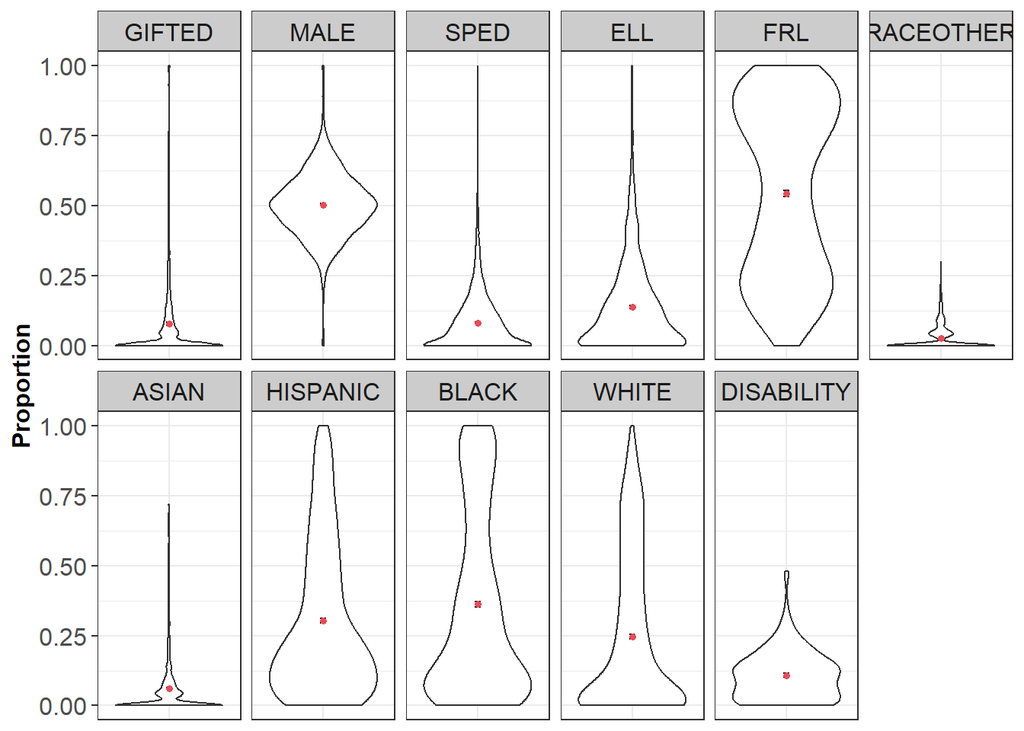

Note. The coral dots represent the weighted means. Error bars represent +/- 1 SE.

Descriptive information on teachers teaching the class sections

| Characteristic | Count | Non-missing observations | Proportion of non-missing observations | Proportion of sample size |
| --- | --- | --- | --- | --- |
| DAD_MALE | 141 | 811 | 0.174 | 0.169 |
| DAD_WHITE | 458 | 809 | 0.566 | 0.550 |
| DAD_BLACK | 295 | 809 | 0.365 | 0.355 |
| DAD_HISPANIC | 40 | 809 | 0.049 | 0.048 |
| DAD_RACEOTHER | 16 | 809 | 0.020 | 0.019 |
| DAD_MASTERSPLUS | 267 | 633 | 0.422 | 0.321 |
| DAD_YRSEXP_NEW | 48 | 301 | 0.159 | 0.058 |
| DAD_YRSEXP_EARLY | 66 | 301 | 0.219 | 0.079 |
| DAD_YRSEXP_EST | 63 | 301 | 0.209 | 0.076 |
| DAD_YRSEXP_EXP | 74 | 301 | 0.246 | 0.089 |
| DAD_YRSEXP_HIGH | 50 | 301 | 0.166 | 0.060 |
| DAD_YRSEXPDIST_NEW | 127 | 622 | 0.204 | 0.153 |
| DAD_YRSEXPDIST_EARLY | 198 | 622 | 0.318 | 0.238 |
| DAD_YRSEXPDIST_EST | 159 | 622 | 0.256 | 0.191 |
| DAD_YRSEXPDIST_EXP | 101 | 622 | 0.162 | 0.121 |
| DAD_YRSEXPDIST_HIGH | 37 | 622 | 0.059 | 0.044 |

Note. This table indicates the counts of teachers in the analytical sample that indicated a certain demographic characteristic. The information may be missing for some teachers in the total sample of 832 teachers.  
Experience was grouped as NEW = [0, 2] years, EARLY = (2, 5] years, EST = (5, 10] years, EXP = (10, 20] years, HIGH = (20, Inf) years.

Descriptive information on teachers teaching the class sections (continued)

| Characteristic | Mean | SD | N |
| --- | --- | --- | --- |
| DAD_YRSEXP | 11.093 | 9.740 | 301 |
| DAD_YRSEXPDIST | 7.178 | 6.701 | 622 |
| DAD_YRSEXP_DIFF | 2.299 | 4.962 | 301 |
| FFT_CEV_adj | 2.684 | 0.232 | 832 |
| VA_MATH_adj | 0.010 | 0.190 | 832 |
| VA_BAM_adj | 0.008 | 0.189 | 832 |

Note. This table indicates mean and SD of teachers in the analytical sample that indicated a certain demographic characteristic. The information may be missing for some teachers in the total sample of 832 teachers.  
DAD_YRSEXP_DIFF is the difference between total teaching experience DAD_YRSEXP and teaching experience in the district DAD_YRSEXPDIST.  
CEV, VA_MATH & VA_BAM represent teacher-level aggregates. FFT scores were adjusted at teacher level. VAMs were adjusted at section level and then aggregated at the teacher level using weighted means, accounting for the pupils included in the section-level VAMs.

Correlation of teaching experience with necessary condition and outcomes

| x | y | cor | ci_l | ci_u | df | t | p | N |
| --- | --- | --- | --- | --- | --- | --- | --- | --- |
| DAD_YRSEXP | FFT_CEV_adj_std | 0.204 | 0.093 | 0.310 | 299 | 3.600 | 0.000 | 301 |
| DAD_YRSEXP | FFT_MSB_adj_std | 0.257 | 0.148 | 0.360 | 299 | 4.603 | 0.000 | 301 |
| DAD_YRSEXP | FFT_MCP_adj_std | 0.183 | 0.071 | 0.290 | 299 | 3.217 | 0.001 | 301 |
| DAD_YRSEXP | FFT_CERR_adj_std | 0.136 | 0.024 | 0.246 | 299 | 2.382 | 0.018 | 301 |
| DAD_YRSEXP | FFT_ECL_adj_std | 0.138 | 0.025 | 0.247 | 299 | 2.407 | 0.017 | 301 |
| DAD_YRSEXP | VA_MATH_adj_std | -0.019 | -0.132 | 0.094 | 299 | -0.333 | 0.739 | 301 |
| DAD_YRSEXP | VA_BAM_adj_std | -0.052 | -0.164 | 0.061 | 299 | -0.905 | 0.366 | 301 |
| DAD_YRSEXPDIST | FFT_CEV_adj_std | 0.114 | 0.036 | 0.191 | 620 | 2.864 | 0.004 | 622 |
| DAD_YRSEXPDIST | FFT_MSB_adj_std | 0.144 | 0.066 | 0.220 | 620 | 3.612 | 0.000 | 622 |
| DAD_YRSEXPDIST | FFT_MCP_adj_std | 0.108 | 0.030 | 0.185 | 620 | 2.714 | 0.007 | 622 |
| DAD_YRSEXPDIST | FFT_CERR_adj_std | 0.077 | -0.001 | 0.155 | 620 | 1.934 | 0.054 | 622 |
| DAD_YRSEXPDIST | FFT_ECL_adj_std | 0.074 | -0.005 | 0.151 | 620 | 1.836 | 0.067 | 622 |
| DAD_YRSEXPDIST | VA_MATH_adj_std | -0.072 | -0.150 | 0.007 | 620 | -1.798 | 0.073 | 622 |
| DAD_YRSEXPDIST | VA_BAM_adj_std | -0.030 | -0.108 | 0.049 | 620 | -0.744 | 0.457 | 622 |

Note. Data on DAD_YRSEXP is available for 301 teachers. Data on DAD_YRSEXPDIST is available for 622 teachers.

Underlying count data for figure - Years of teaching experience

| YRSEXP | Domain | Mean | SD | N |
| --- | --- | --- | --- | --- |
| [0, 2] | CEV | -0.82 | 1.27 | 48 |
| [0, 2] | MATH | -0.14 | 0.94 | 48 |
| [0, 2] | BAM | -0.04 | 0.95 | 48 |
| (2, 4] | CEV | -0.14 | 1.05 | 45 |
| (2, 4] | MATH | -0.11 | 0.75 | 45 |
| (2, 4] | BAM | 0.06 | 0.64 | 45 |
| (4, 6] | CEV | 0.01 | 0.95 | 36 |
| (4, 6] | MATH | 0.02 | 0.69 | 36 |
| (4, 6] | BAM | -0.03 | 0.70 | 36 |
| (6, 8] | CEV | -0.10 | 1.10 | 25 |
| (6, 8] | MATH | 0.07 | 0.58 | 25 |
| (6, 8] | BAM | -0.12 | 0.86 | 25 |
| (8, 10] | CEV | 0.31 | 0.79 | 23 |
| (8, 10] | MATH | 0.16 | 0.64 | 23 |
| (8, 10] | BAM | 0.00 | 0.74 | 23 |
| (10, 12] | CEV | 0.27 | 0.59 | 25 |
| (10, 12] | MATH | 0.07 | 0.68 | 25 |
| (10, 12] | BAM | 0.15 | 0.86 | 25 |
| (12, 14] | CEV | 0.25 | 0.82 | 15 |
| (12, 14] | MATH | -0.05 | 0.74 | 15 |
| (12, 14] | BAM | 0.04 | 0.62 | 15 |
| (14, 16] | CEV | 0.15 | 1.25 | 14 |
| (14, 16] | MATH | -0.36 | 0.84 | 14 |
| (14, 16] | BAM | -0.09 | 0.43 | 14 |
| (16, 18] | CEV | 0.01 | 0.84 | 15 |
| (16, 18] | MATH | -0.23 | 0.57 | 15 |
| (16, 18] | BAM | -0.28 | 0.87 | 15 |
| (18, Inf) | CEV | 0.17 | 0.83 | 55 |
| (18, Inf) | MATH | -0.12 | 0.85 | 55 |
| (18, Inf) | BAM | -0.11 | 0.70 | 55 |

#### **Figure**

#### *Relationship between teaching experience, necessary condition and outcomes*

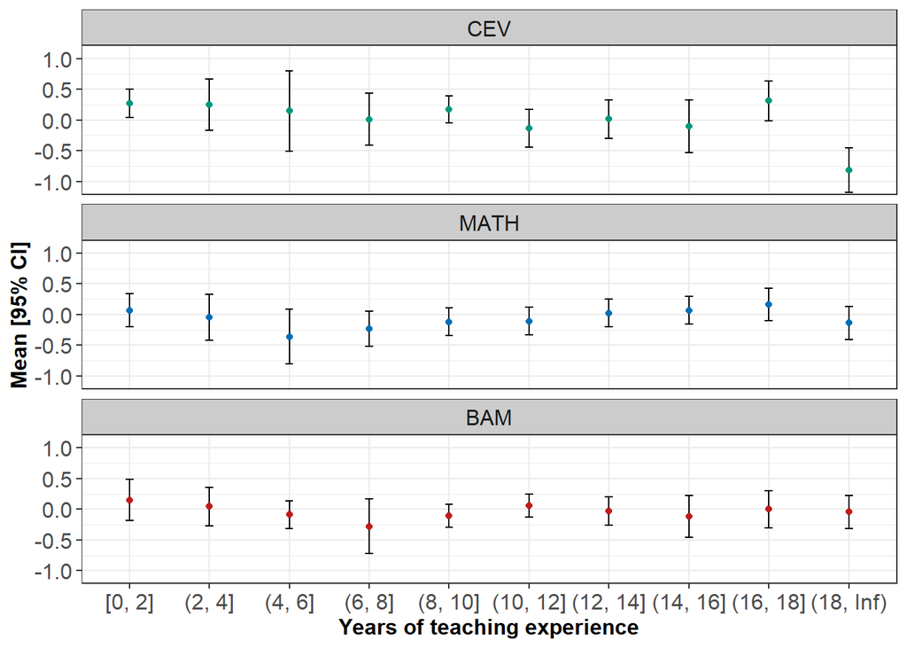

Underlying count data for figure - Years of teaching experience in dictrict

| YRSEXPDIST | Domain | Mean | SD | N |
| --- | --- | --- | --- | --- |
| [0, 2] | CEV | -0.33 | 1.20 | 127 |
| [0, 2] | MATH | 0.00 | 1.09 | 127 |
| [0, 2] | BAM | -0.06 | 1.29 | 127 |
| (2, 4] | CEV | 0.08 | 0.91 | 118 |
| (2, 4] | MATH | 0.07 | 1.07 | 118 |
| (2, 4] | BAM | 0.00 | 0.84 | 118 |
| (4, 6] | CEV | 0.03 | 0.91 | 119 |
| (4, 6] | MATH | 0.06 | 1.02 | 119 |
| (4, 6] | BAM | 0.10 | 0.84 | 119 |
| (6, 8] | CEV | -0.05 | 1.03 | 69 |
| (6, 8] | MATH | -0.10 | 0.89 | 69 |
| (6, 8] | BAM | -0.16 | 1.09 | 69 |
| (8, 10] | CEV | 0.19 | 0.90 | 51 |
| (8, 10] | MATH | 0.03 | 1.18 | 51 |
| (8, 10] | BAM | 0.17 | 1.01 | 51 |
| (10, 12] | CEV | 0.05 | 0.78 | 38 |
| (10, 12] | MATH | 0.05 | 1.07 | 38 |
| (10, 12] | BAM | 0.03 | 1.08 | 38 |
| (12, 14] | CEV | 0.23 | 0.78 | 21 |
| (12, 14] | MATH | -0.22 | 1.04 | 21 |
| (12, 14] | BAM | 0.49 | 1.27 | 21 |
| (14, 16] | CEV | 0.26 | 1.11 | 20 |
| (14, 16] | MATH | -0.21 | 0.90 | 20 |
| (14, 16] | BAM | 0.17 | 0.98 | 20 |
| (16, 18] | CEV | 0.18 | 0.77 | 17 |
| (16, 18] | MATH | -0.32 | 1.34 | 17 |
| (16, 18] | BAM | -0.05 | 0.88 | 17 |
| (18, Inf) | CEV | 0.13 | 0.90 | 42 |
| (18, Inf) | MATH | -0.24 | 0.74 | 42 |
| (18, Inf) | BAM | -0.27 | 0.72 | 42 |

#### **Figure**

#### *Relationship between teaching experience in district, necessary condition and outcomes*

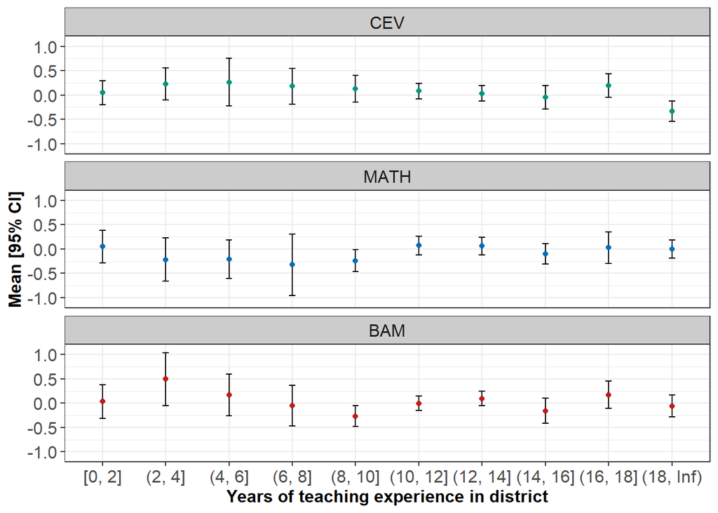

Underlying count data for figure - Years of teaching experience

| DAD_YRSEXP_GRP | Domain | Mean | SD | N |
| --- | --- | --- | --- | --- |
| [0, 2] | CEV | -0.82 | 1.27 | 48 |
| [0, 2] | MATH | -0.14 | 0.94 | 48 |
| [0, 2] | BAM | -0.04 | 0.95 | 48 |
| (2, 5] | CEV | -0.11 | 1.02 | 66 |
| (2, 5] | MATH | -0.11 | 0.68 | 66 |
| (2, 5] | BAM | 0.01 | 0.63 | 66 |
| (5, 10] | CEV | 0.10 | 0.96 | 63 |
| (5, 10] | MATH | 0.14 | 0.67 | 63 |
| (5, 10] | BAM | -0.03 | 0.80 | 63 |
| (10, 20] | CEV | 0.19 | 0.83 | 74 |
| (10, 20] | MATH | -0.10 | 0.72 | 74 |
| (10, 20] | BAM | -0.04 | 0.74 | 74 |
| (20, Inf) | CEV | 0.16 | 0.85 | 50 |
| (20, Inf) | MATH | -0.12 | 0.85 | 50 |
| (20, Inf) | BAM | -0.08 | 0.71 | 50 |

#### **Figure**

#### *Relationship between teaching experience, necessary condition and outcomes*

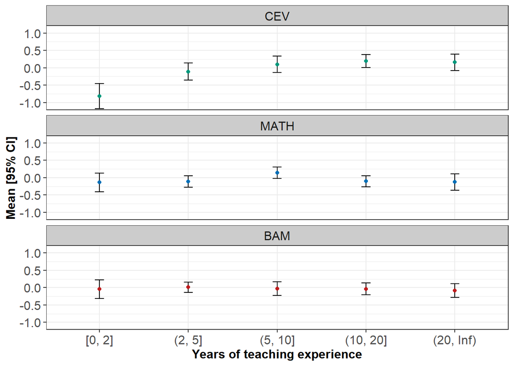

Underlying count data for figure - Years of teaching experience in the district

| DAD_YRSEXPDIST_GRP | Domain | Mean | SD | N |
| --- | --- | --- | --- | --- |
| [0, 2] | CEV | -0.33 | 1.20 | 127 |
| [0, 2] | MATH | 0.00 | 1.09 | 127 |
| [0, 2] | BAM | -0.06 | 1.29 | 127 |
| (2, 5] | CEV | 0.05 | 0.90 | 198 |
| (2, 5] | MATH | 0.02 | 1.00 | 198 |
| (2, 5] | BAM | 0.04 | 0.82 | 198 |
| (5, 10] | CEV | 0.06 | 0.96 | 159 |
| (5, 10] | MATH | 0.04 | 1.08 | 159 |
| (5, 10] | BAM | 0.01 | 1.04 | 159 |
| (10, 20] | CEV | 0.14 | 0.85 | 101 |
| (10, 20] | MATH | -0.16 | 1.06 | 101 |
| (10, 20] | BAM | 0.12 | 1.06 | 101 |
| (20, Inf) | CEV | 0.16 | 0.91 | 37 |
| (20, Inf) | MATH | -0.18 | 0.73 | 37 |
| (20, Inf) | BAM | -0.25 | 0.73 | 37 |

#### **Figure**

#### *Relationship between teaching experience in district, necessary condition and outcomes*

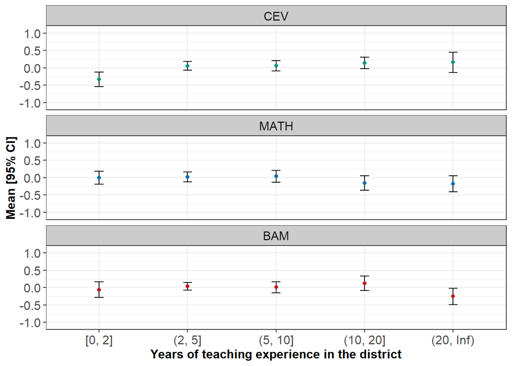

Within vs between school variation - section level

| Domain | avg_within_sd | within_var | between_sd | between_var | total_var | within_pct | between_pct |
| --- | --- | --- | --- | --- | --- | --- | --- |
| FFT_CEV_adj | 0.159 | 0.033 | 0.167 | 0.028 | 0.061 | 0.540 | 0.460 |
| VA_BAM_adj | 0.161 | 0.034 | 0.122 | 0.015 | 0.049 | 0.696 | 0.304 |
| VA_MATH_adj | 0.147 | 0.029 | 0.136 | 0.019 | 0.047 | 0.606 | 0.394 |

Note. Data is available for 1152 classrooms. avg_within_sd is the average within-school SD. between_sd is the SD of school means. Classrooms were not aggregated at teacher-level before aggregating at school level.

Within vs between school variation - teacher level

| Domain | avg_within_sd | within_var | between_sd | between_var | total_var | within_pct | between_pct |
| --- | --- | --- | --- | --- | --- | --- | --- |
| FFT_CEV_adj | 0.165 | 0.038 | 0.187 | 0.035 | 0.074 | 0.523 | 0.477 |
| VA_BAM_adj | 0.144 | 0.029 | 0.124 | 0.015 | 0.044 | 0.652 | 0.348 |
| VA_MATH_adj | 0.140 | 0.028 | 0.137 | 0.019 | 0.047 | 0.597 | 0.403 |

Note. Data is available for 832 Teachers avg_within_sd is the average within-school SD. between_sd is the SD of school means. Classrooms were aggregated at teacher-level before aggregating at school level.

## Framework for Teaching (FFT)

Segment-level data is available for 10691 lesson segments.

Underlying count data for Observation score distributions figure

| item | domain | value | count |
| --- | --- | --- | --- |
| FFT_MSB | Classroom environment (FFT_CEV) | 1 | 267 |
| FFT_MSB | Classroom environment (FFT_CEV) | 2 | 1975 |
| FFT_MSB | Classroom environment (FFT_CEV) | 3 | 7811 |
| FFT_MSB | Classroom environment (FFT_CEV) | 4 | 468 |
| FFT_MSB | Classroom environment (FFT_CEV) |  | 170 |
| FFT_MCP | Classroom environment (FFT_CEV) | 1 | 325 |
| FFT_MCP | Classroom environment (FFT_CEV) | 2 | 2589 |
| FFT_MCP | Classroom environment (FFT_CEV) | 3 | 7289 |
| FFT_MCP | Classroom environment (FFT_CEV) | 4 | 320 |
| FFT_MCP | Classroom environment (FFT_CEV) |  | 168 |
| FFT_CERR | Classroom environment (FFT_CEV) | 1 | 340 |
| FFT_CERR | Classroom environment (FFT_CEV) | 2 | 2534 |
| FFT_CERR | Classroom environment (FFT_CEV) | 3 | 7342 |
| FFT_CERR | Classroom environment (FFT_CEV) | 4 | 337 |
| FFT_CERR | Classroom environment (FFT_CEV) |  | 138 |
| FFT_ECL | Classroom environment (FFT_CEV) | 1 | 322 |
| FFT_ECL | Classroom environment (FFT_CEV) | 2 | 4192 |
| FFT_ECL | Classroom environment (FFT_CEV) | 3 | 5765 |
| FFT_ECL | Classroom environment (FFT_CEV) | 4 | 244 |
| FFT_ECL | Classroom environment (FFT_CEV) |  | 168 |
| FFT_UQDT | Instruction (FFT_INS) | 1 | 979 |
| FFT_UQDT | Instruction (FFT_INS) | 2 | 6209 |
| FFT_UQDT | Instruction (FFT_INS) | 3 | 3264 |
| FFT_UQDT | Instruction (FFT_INS) | 4 | 103 |
| FFT_UQDT | Instruction (FFT_INS) |  | 136 |
| FFT_CS | Instruction (FFT_INS) | 1 | 172 |
| FFT_CS | Instruction (FFT_INS) | 2 | 3746 |
| FFT_CS | Instruction (FFT_INS) | 3 | 6322 |
| FFT_CS | Instruction (FFT_INS) | 4 | 283 |
| FFT_CS | Instruction (FFT_INS) |  | 168 |
| FFT_ESL | Instruction (FFT_INS) | 1 | 306 |
| FFT_ESL | Instruction (FFT_INS) | 2 | 5257 |
| FFT_ESL | Instruction (FFT_INS) | 3 | 4669 |
| FFT_ESL | Instruction (FFT_INS) | 4 | 292 |
| FFT_ESL | Instruction (FFT_INS) |  | 167 |
| FFT_UAI | Instruction (FFT_INS) | 1 | 578 |
| FFT_UAI | Instruction (FFT_INS) | 2 | 6016 |
| FFT_UAI | Instruction (FFT_INS) | 3 | 3725 |
| FFT_UAI | Instruction (FFT_INS) | 4 | 205 |
| FFT_UAI | Instruction (FFT_INS) |  | 167 |

Note. The data shows the count of lesson video segments that have received a certain rating value for each domain of the FFT.

#### **Figure**

#### *Observation score distributions*

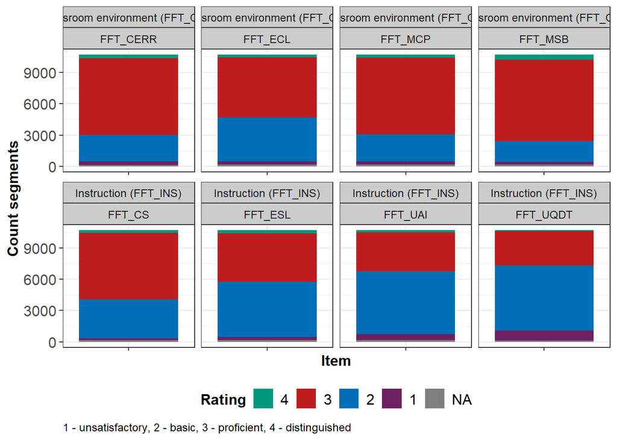

#### **Figure**

#### *Unadjusted observation scores aggregated at classroom level*

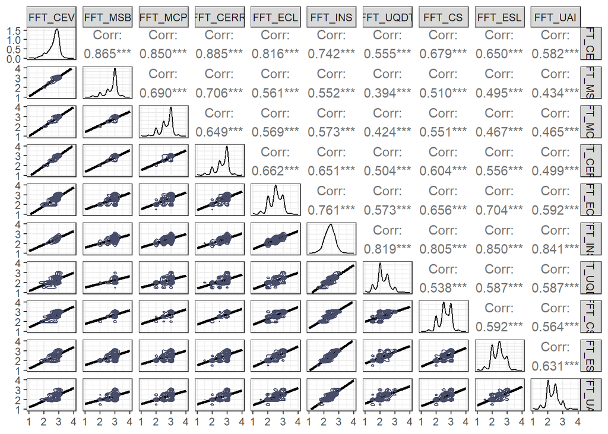

#### **Figure**

#### *Unadjusted observation scores aggregated at classroom level*

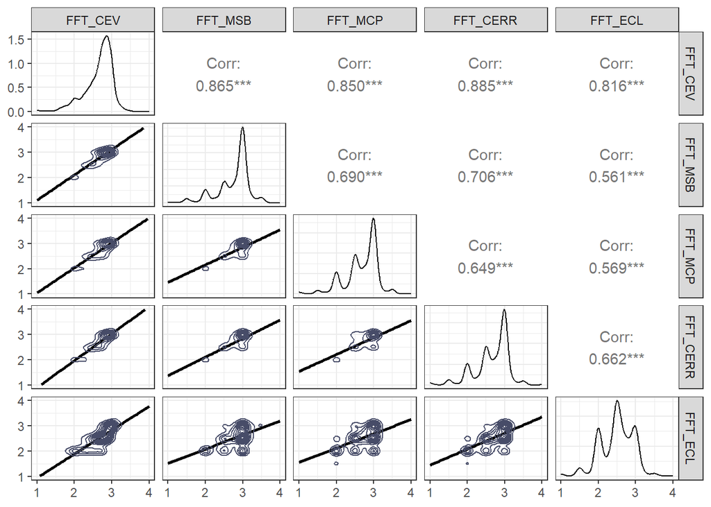

#### **Figure**

#### *Distribution of raw and adjusted observation scores*

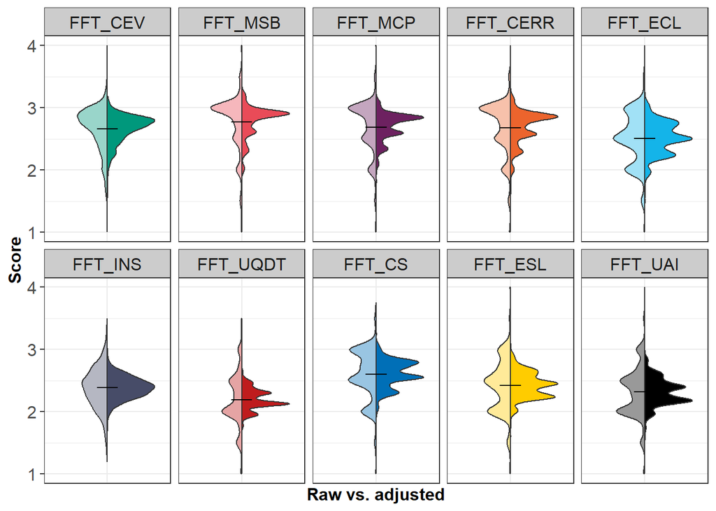

Raw observation scores

| Domain | Weighted mean | Weighted SD |
| --- | --- | --- |
| FFT_CEV | 2.65 | 0.38 |
| FFT_MSB | 2.75 | 0.44 |
| FFT_MCP | 2.67 | 0.44 |
| FFT_CERR | 2.66 | 0.46 |
| FFT_ECL | 2.49 | 0.43 |
| FFT_INS | 2.37 | 0.34 |
| FFT_UQDT | 2.18 | 0.41 |
| FFT_CS | 2.59 | 0.39 |
| FFT_ESL | 2.41 | 0.42 |
| FFT_UAI | 2.30 | 0.42 |

Note. Data from 1152 classrooms is included. Weighted means and SDs are calculated using the class size. Weighted statistics reflect the distribution of each characteristic across all pupils in the sample.  
FFT_CEV and FFT_INS refer to the domain scores for classroom environment and instruction, respectively, computed as the mean of their indicators.

Adjusted observation scores

| Domain | Weighted mean | Weighted SD |
| --- | --- | --- |
| FFT_CEV | 2.66 | 0.23 |
| FFT_MSB | 2.76 | 0.28 |
| FFT_MCP | 2.68 | 0.24 |
| FFT_CERR | 2.67 | 0.28 |
| FFT_ECL | 2.51 | 0.26 |
| FFT_INS | 2.38 | 0.17 |
| FFT_UQDT | 2.19 | 0.17 |
| FFT_CS | 2.61 | 0.22 |
| FFT_ESL | 2.42 | 0.21 |
| FFT_UAI | 2.31 | 0.21 |

Note. Data from 1152 classrooms is included. Weighted means and SDs are calculated using the class size. Weighted statistics reflect the distribution of each characteristic across all pupils in the sample.

#### **Figure**

#### *Relationship between raw and adjusted observation scores*

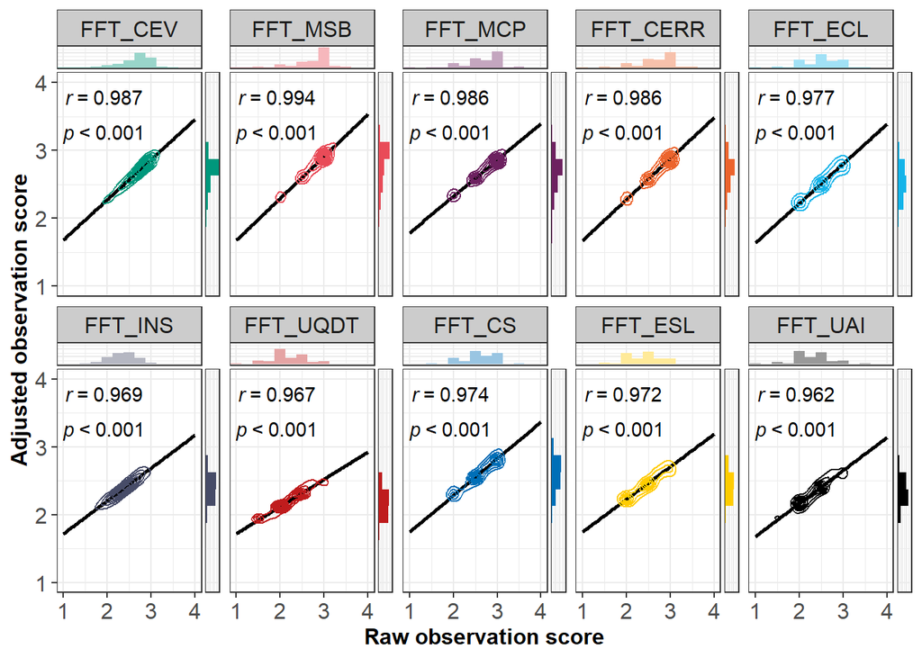

#### **Figure**

#### *Raw and adjusted observation scores*

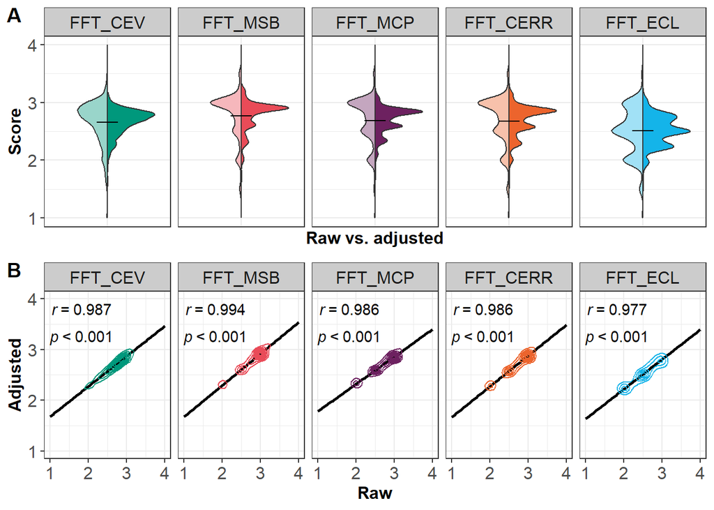

#### **Figure**

#### *Adjusted observation scores aggregated at classroom level*

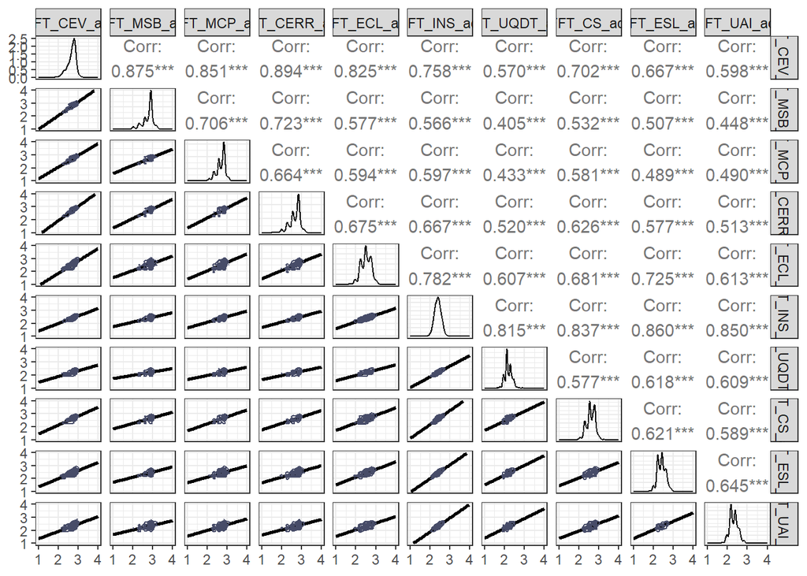

#### **Figure**

#### *Adjusted observation scores aggregated at classroom level*

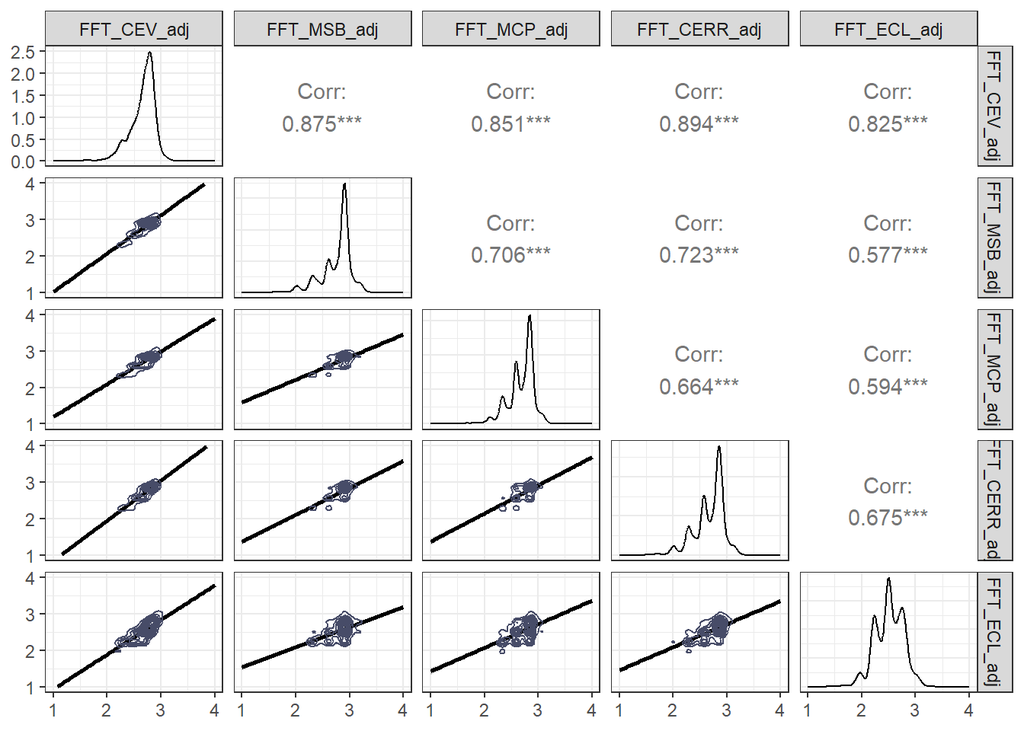